# Modeling thermal trade-offs versus trade-ups in a Resistance-vs-Recovery framework

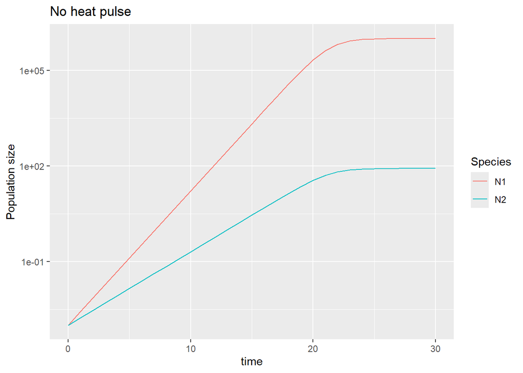

```r
# simulate the community WITHOUT heat pulse (i.e., no heat control)
simCTRL <- sim_1temp(time = 0:heat_pulse_times[3],
                   init = State,
                   params = c(K=carrying_cap, mu1=sp1_ambient, mu2=sp2_ambient))
# plot the no heat control:
ggplot(pivot_longer(simCTRL, cols = N1:N2),
       aes(x=time, y=value, colour=name)) +
  geom_line() +
  labs(title = "No heat pulse", y="Population size", colour = "Species") +
  scale_y_log10()
```

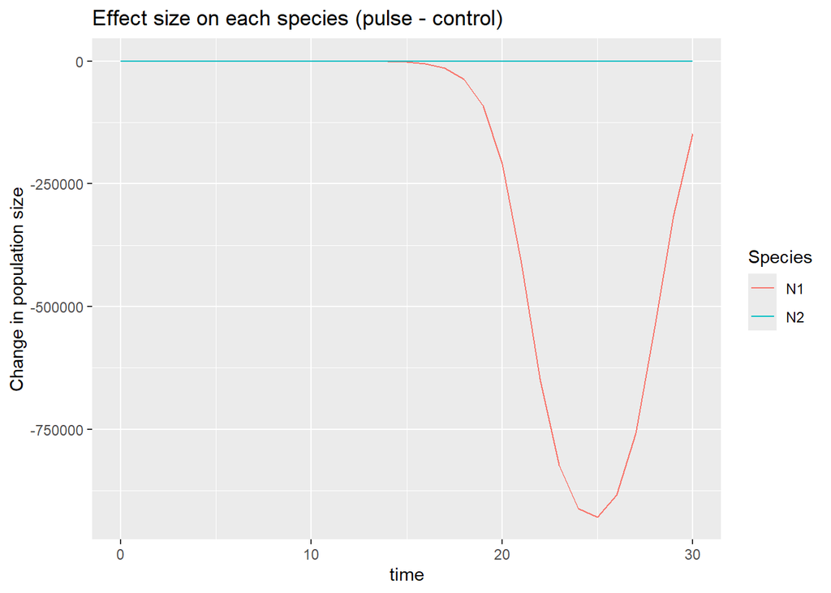

```r
################ let's look at the effect size in different ways:
effects_df <- heatVScontrol_effect(simdata_heat=simEX, simdata_control=simCTRL)

# plot per species
ggplot(effects_df %>%
         select(time, N1, N2) %>% pivot_longer(cols = N1:N2),
       aes(x=time, y=value, colour=name)) +
  geom_line() +
  labs(title = "Effect size on each species (pulse - control)", y="Change in population size", colour = "Species")
```

```r
# total productivity
ggplot(effects_df %>%
         select(time, productivity),
       aes(x=time, y=productivity)) +
  geom_line() +
  labs(title = "Effect size on total productivity (pulse - control)", y="Change in productivity")
```

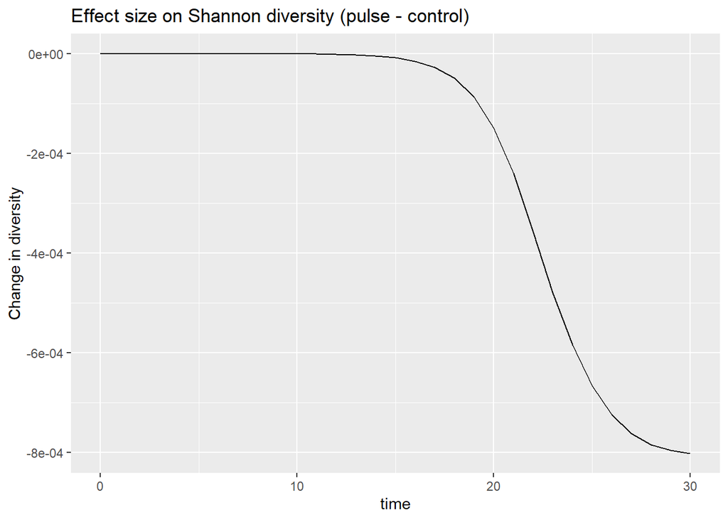

```r
# Shannon diversity
ggplot(effects_df %>%
         select(time, diversity),
       aes(x=time, y=diversity)) +
  geom_line() +
  labs(title = "Effect size on Shannon diversity (pulse - control)", y="Change in diversity")
```

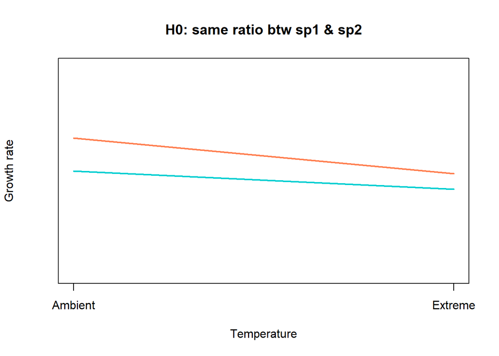

```r
# finally, we store the resistance vs recovery values for both productivity and diversity
temp <- data.frame(prod_resist = effects_df$productivity[which(effects_df$time == heat_pulse_times[2])],
                    prod_recov = effects_df$productivity[which(effects_df$time == heat_pulse_times[3])],
                    div_resist = effects_df$diversity[which(effects_df$time == heat_pulse_times[2])],
                    div_recov = effects_df$diversity[which(effects_df$time == heat_pulse_times[3])],
                    spF_ambient = sp1_ambient,
                    spF_extreme = sp1_extreme,
                    spS_ambient = sp2_ambient,
                    spS_extreme = sp2_extreme,
                    hypoth = "H0: same distance")
RR_df <- rbind(RR_df, temp)
rm(temp)
# clear memory
rm(simEX, simCTRL, effects_df)

##################################### now we do same ratio again:
sp2_ambient <- 0.4947
sp2_extreme <- 0.2346

plot_muSchematic(fast_ambient = sp1_ambient, fast_extreme = sp1_extreme,
                 slo_ambient = sp2_ambient, slo_extreme = sp2_extreme,
                 plot_title = "H0: same ratio btw sp1 & sp2")
```

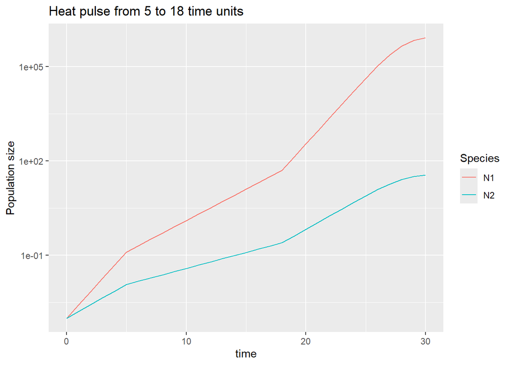

```r
# simulate the community with heat pulse
simEX <- sim_pulse(times=heat_pulse_times, init=State, K=carrying_cap,
                   mu_ambient=c(mu1=sp1_ambient, mu2=sp2_ambient), mu_extreme=c(mu1=sp1_extreme, mu2=sp2_extreme))

# plot the example under heat pulse conditions
ggplot(pivot_longer(simEX, cols = N1:N2),
       aes(x=time, y=value, colour=name)) +
  geom_line() +
  labs(title = "Heat pulse from 5 to 18 time units", y="Population size", colour = "Species") +
  scale_y_log10()
```

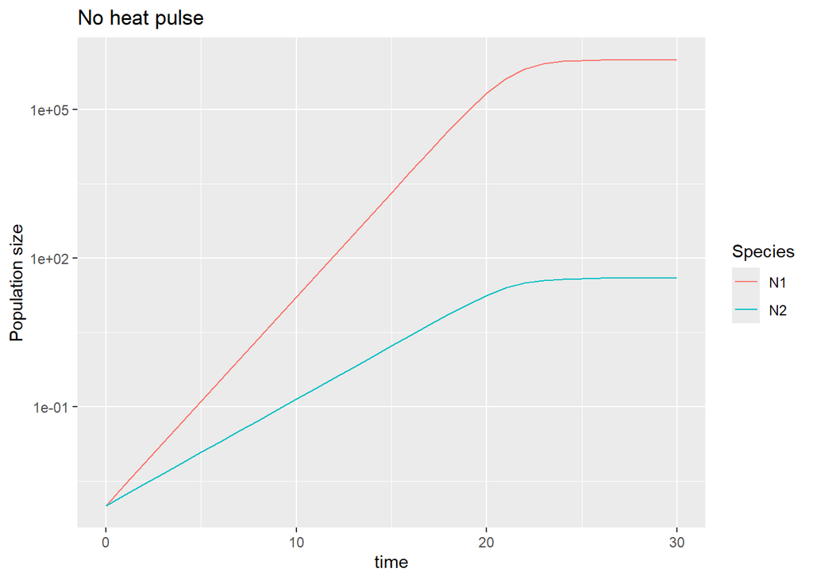

```r
# simulate the community WITHOUT heat pulse (i.e., no heat control)
simCTRL <- sim_1temp(time = 0:heat_pulse_times[3],
                   init = State,
                   params = c(K=carrying_cap, mu1=sp1_ambient, mu2=sp2_ambient))
# plot the no heat control:
ggplot(pivot_longer(simCTRL, cols = N1:N2),
       aes(x=time, y=value, colour=name)) +
  geom_line() +
  labs(title = "No heat pulse", y="Population size", colour = "Species") +
  scale_y_log10()
```

```r
################ let's look at the effect size in different ways:
effects_df <- heatVScontrol_effect(simdata_heat=simEX, simdata_control=simCTRL)

# plot per species
ggplot(effects_df %>%
         select(time, N1, N2) %>% pivot_longer(cols = N1:N2),
       aes(x=time, y=value, colour=name)) +
  geom_line() +
  labs(title = "Effect size on each species (pulse - control)", y="Change in population size", colour = "Species")
```

```r
# total productivity
ggplot(effects_df %>%
         select(time, productivity),
       aes(x=time, y=productivity)) +
  geom_line() +
  labs(title = "Effect size on total productivity (pulse - control)", y="Change in productivity")
```

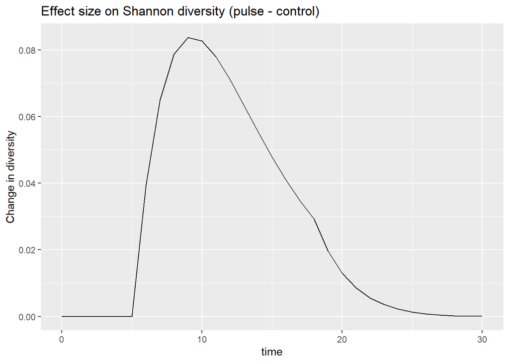

```r
# Shannon diversity
ggplot(effects_df %>%
         select(time, diversity),
       aes(x=time, y=diversity)) +
  geom_line() +
  labs(title = "Effect size on Shannon diversity (pulse - control)", y="Change in diversity")
```

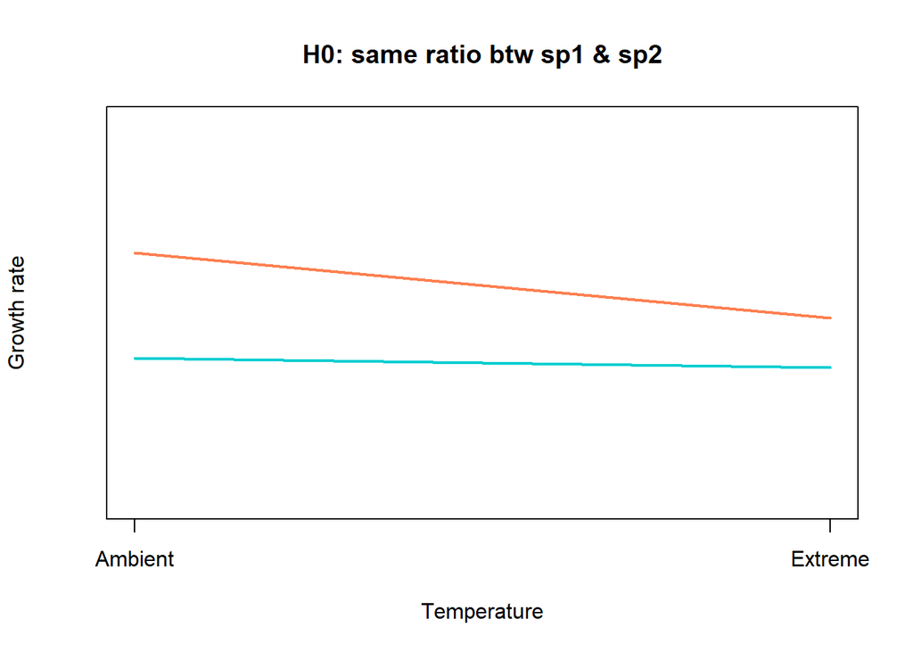

```r
# finally, we store the resistance vs recovery values for both productivity and diversity
temp <- data.frame(prod_resist = effects_df$productivity[which(effects_df$time == heat_pulse_times[2])],
                    prod_recov = effects_df$productivity[which(effects_df$time == heat_pulse_times[3])],
                    div_resist = effects_df$diversity[which(effects_df$time == heat_pulse_times[2])],
                    div_recov = effects_df$diversity[which(effects_df$time == heat_pulse_times[3])],
                    spF_ambient = sp1_ambient,
                    spF_extreme = sp1_extreme,
                    spS_ambient = sp2_ambient,
                    spS_extreme = sp2_extreme,
                    hypoth = "H0: same ratio")
RR_df <- rbind(RR_df, temp)
rm(temp)
# clear memory
rm(simEX, simCTRL, effects_df)


##################################### we do same ratio aaaaand yet again:
sp2_ambient <- 0.1455
sp2_extreme <- 0.069

plot_muSchematic(fast_ambient = sp1_ambient, fast_extreme = sp1_extreme,
                 slo_ambient = sp2_ambient, slo_extreme = sp2_extreme,
                 plot_title = "H0: same ratio btw sp1 & sp2")
```

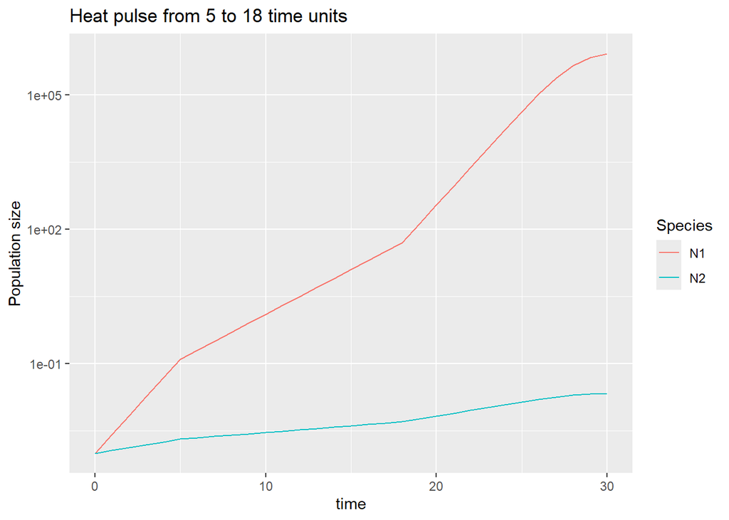

```r
# simulate the community with heat pulse
simEX <- sim_pulse(times=heat_pulse_times, init=State, K=carrying_cap,
                   mu_ambient=c(mu1=sp1_ambient, mu2=sp2_ambient), mu_extreme=c(mu1=sp1_extreme, mu2=sp2_extreme))

# plot the example under heat pulse conditions
ggplot(pivot_longer(simEX, cols = N1:N2),
       aes(x=time, y=value, colour=name)) +
  geom_line() +
  labs(title = "Heat pulse from 5 to 18 time units", y="Population size", colour = "Species") +
  scale_y_log10()
```

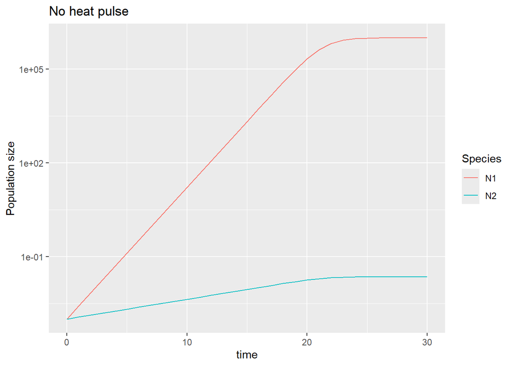

```r
# simulate the community WITHOUT heat pulse (i.e., no heat control)
simCTRL <- sim_1temp(time = 0:heat_pulse_times[3],
                   init = State,
                   params = c(K=carrying_cap, mu1=sp1_ambient, mu2=sp2_ambient))
# plot the no heat control:
ggplot(pivot_longer(simCTRL, cols = N1:N2),
       aes(x=time, y=value, colour=name)) +
  geom_line() +
  labs(title = "No heat pulse", y="Population size", colour = "Species") +
  scale_y_log10()
```

```r
################ let's look at the effect size in different ways:
effects_df <- heatVScontrol_effect(simdata_heat=simEX, simdata_control=simCTRL)

# plot per species
ggplot(effects_df %>%
         select(time, N1, N2) %>% pivot_longer(cols = N1:N2),
       aes(x=time, y=value, colour=name)) +
  geom_line() +
  labs(title = "Effect size on each species (pulse - control)", y="Change in population size", colour = "Species")
```

```r
# total productivity
ggplot(effects_df %>%
         select(time, productivity),
       aes(x=time, y=productivity)) +
  geom_line() +
  labs(title = "Effect size on total productivity (pulse - control)", y="Change in productivity")
```

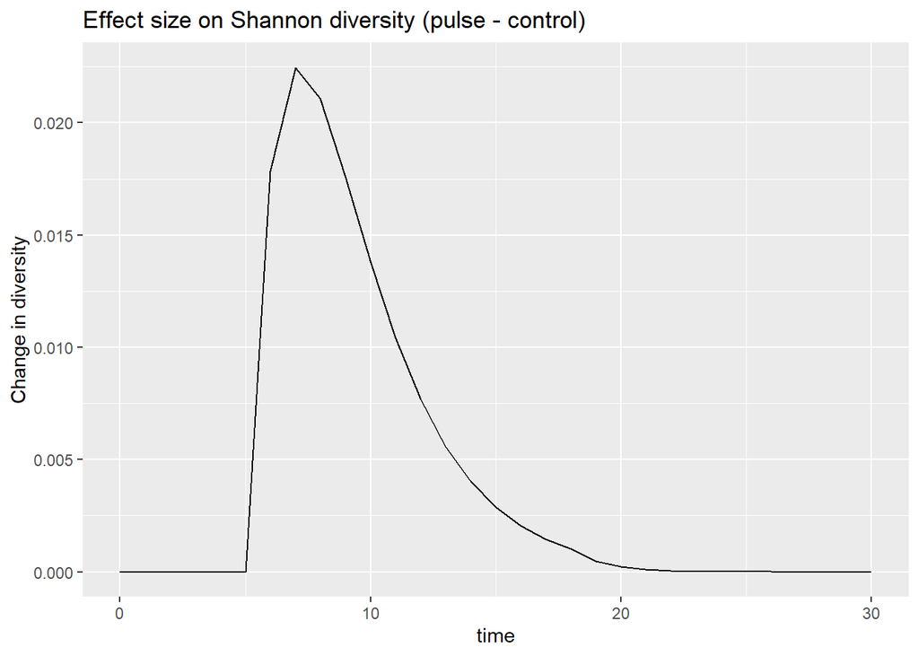

```r
# Shannon diversity
ggplot(effects_df %>%
         select(time, diversity),
       aes(x=time, y=diversity)) +
  geom_line() +
  labs(title = "Effect size on Shannon diversity (pulse - control)", y="Change in diversity")
```

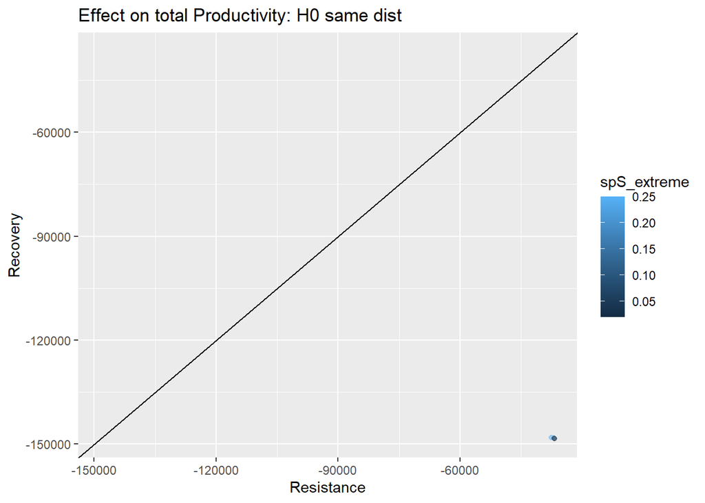

```r
# finally, we store the resistance vs recovery values for both productivity and diversity
temp <- data.frame(prod_resist = effects_df$productivity[which(effects_df$time == heat_pulse_times[2])],
                    prod_recov = effects_df$productivity[which(effects_df$time == heat_pulse_times[3])],
                    div_resist = effects_df$diversity[which(effects_df$time == heat_pulse_times[2])],
                    div_recov = effects_df$diversity[which(effects_df$time == heat_pulse_times[3])],
                    spF_ambient = sp1_ambient,
                    spF_extreme = sp1_extreme,
                    spS_ambient = sp2_ambient,
                    spS_extreme = sp2_extreme,
                    hypoth = "H0: same ratio")
RR_df <- rbind(RR_df, temp)
rm(temp)
# clear memory
rm(simEX, simCTRL, effects_df)

##################### Finally we plot resistance vs recovery
ggplot(RR_df %>% filter(hypoth == "H0: same distance"),
       aes(x = prod_resist, y = prod_recov, colour = spS_extreme)) +
  geom_point(alpha=0.5) +
  geom_abline(intercept = 0, slope = 1, color = "black") +
  xlim(range(unlist(RR_df[,1:2]))) +
  ylim(range(unlist(RR_df[,1:2]))) +
  labs(title = "Effect on total Productivity: H0 same dist", x="Resistance", y="Recovery")
```

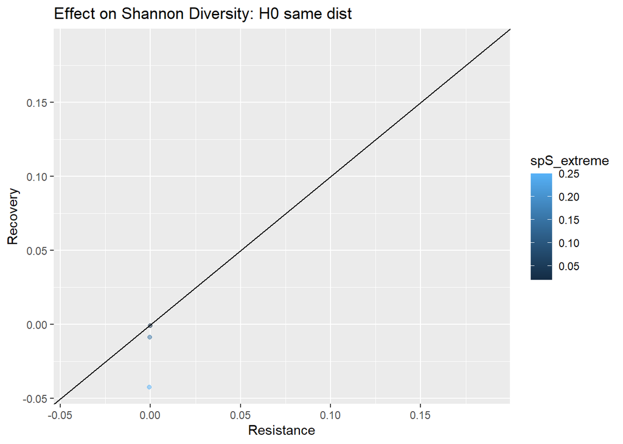

```r
ggplot(RR_df %>% filter(hypoth == "H0: same distance"),
       aes(x = div_resist, y = div_recov, colour = spS_extreme)) +
  geom_point(alpha=0.5) +
  geom_abline(intercept = 0, slope = 1, color = "black") +
  xlim(range(unlist(RR_df[,3:4]))) +
  ylim(range(unlist(RR_df[,3:4]))) +
  labs(title = "Effect on Shannon Diversity: H0 same dist", x="Resistance", y="Recovery")
```

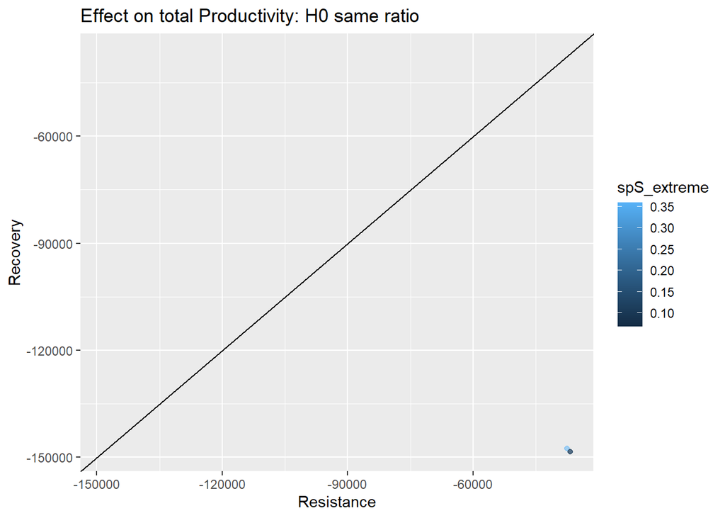

```r
ggplot(RR_df %>% filter(hypoth == "H0: same ratio"),
       aes(x = prod_resist, y = prod_recov, colour = spS_extreme)) +
  geom_point(alpha=0.5) +
  geom_abline(intercept = 0, slope = 1, color = "black") +
  xlim(range(unlist(RR_df[,1:2]))) +
  ylim(range(unlist(RR_df[,1:2]))) +
  labs(title = "Effect on total Productivity: H0 same ratio", x="Resistance", y="Recovery")
```

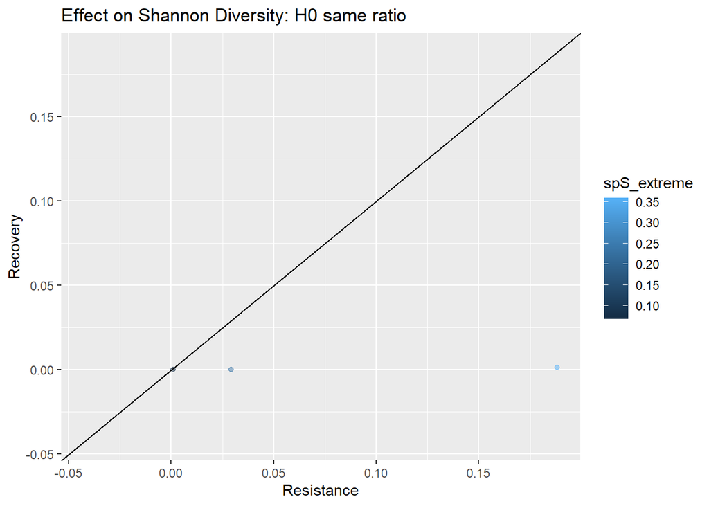

```r
ggplot(RR_df %>% filter(hypoth == "H0: same ratio"),
       aes(x = div_resist, y = div_recov, colour = spS_extreme)) +
  geom_point(alpha=0.5) +
  geom_abline(intercept = 0, slope = 1, color = "black") +
  xlim(range(unlist(RR_df[,3:4]))) +
  ylim(range(unlist(RR_df[,3:4]))) +
  labs(title = "Effect on Shannon Diversity: H0 same ratio", x="Resistance", y="Recovery")
```

```r
# create a variable for storage to plot in the summary figure
final_RR_df <- RR_df %>% filter(hypoth == "H0: same distance")
```

Okay so it seems that under the null hypothesis with positive values of growth rate, **productivity *cannot* be coupled.** Only diversity can be coupled when there’s a sufficiently large difference in growth rate between the fast and slow growing species.

Note that when we have the fixed distance, the effect size on Shannon diversity is always negative. But when we have the same ratio, then the effect size is always positive. I wonder why this happens (and why the shape of the diversity effect size is changing in a funny way)?

### logistic, negative growth

So here I’m letting the slow grower die during the heat pulse to see how that changes things. Note that the same ratio doesn’t work anymore so we drop it for now.

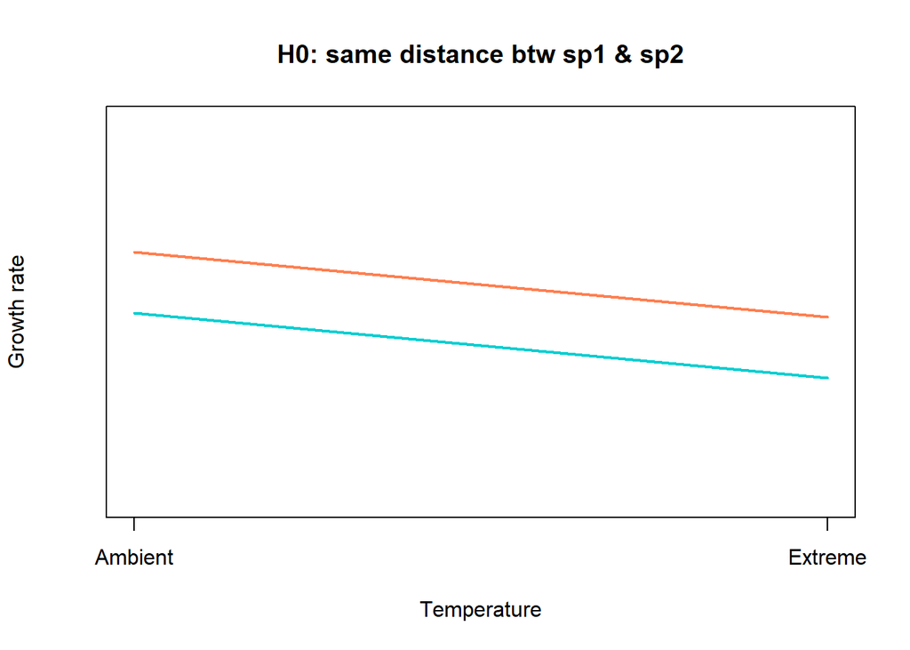

```r
# For the same distance, keep these parameter values fixed to the same values we used before:
## They are written again but commented out just as a reminder!
#State <- c(N1=0.001, N2=0.001)
#heat_pulse_times <- c(5,18,30)
#carrying_cap <- 10^6
#sp1_ambient <- 0.97
#sp1_extreme <- 0.46

# just modify these two parameter values:
sp2_ambient <- 0.49
sp2_extreme <- -0.02

plot_muSchematic(fast_ambient = sp1_ambient, fast_extreme = sp1_extreme,
                 slo_ambient = sp2_ambient, slo_extreme = sp2_extreme,
                 plot_title = "H0: same distance btw sp1 & sp2")
```

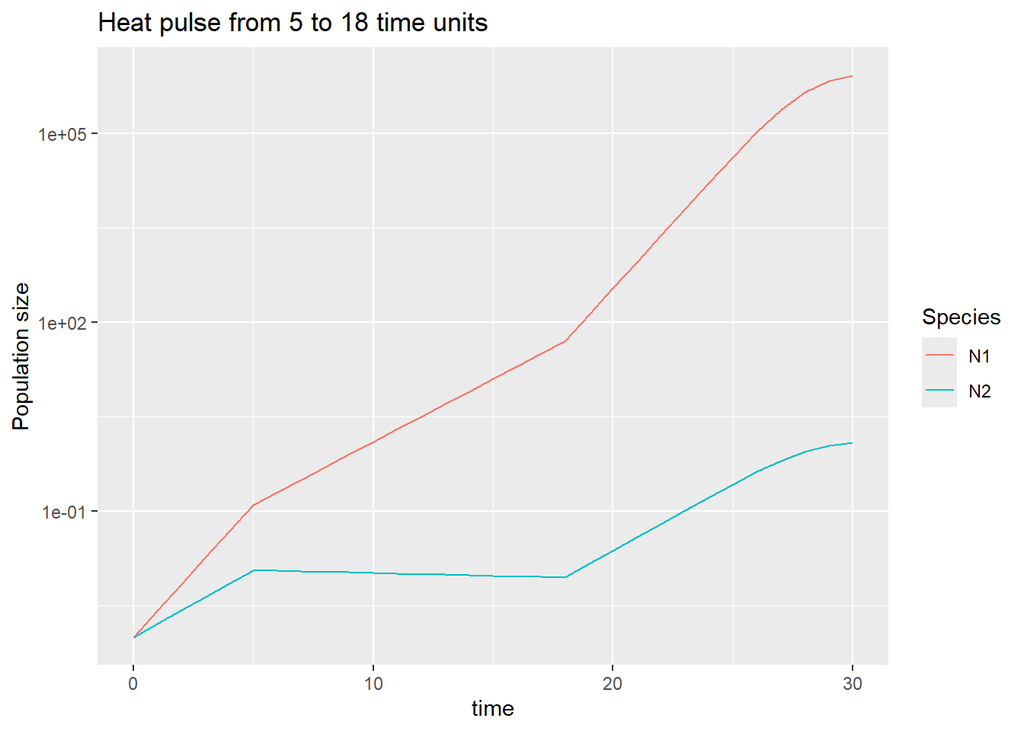

```r
# simulate the community with heat pulse
simEX <- sim_pulse(times=heat_pulse_times, init=State, K=carrying_cap,
                   mu_ambient=c(mu1=sp1_ambient, mu2=sp2_ambient), mu_extreme=c(mu1=sp1_extreme, mu2=sp2_extreme))

# plot the example under heat pulse conditions
ggplot(pivot_longer(simEX, cols = N1:N2),
       aes(x=time, y=value, colour=name)) +
  geom_line() +
  labs(title = "Heat pulse from 5 to 18 time units", y="Population size", colour = "Species") +
  scale_y_log10()
```

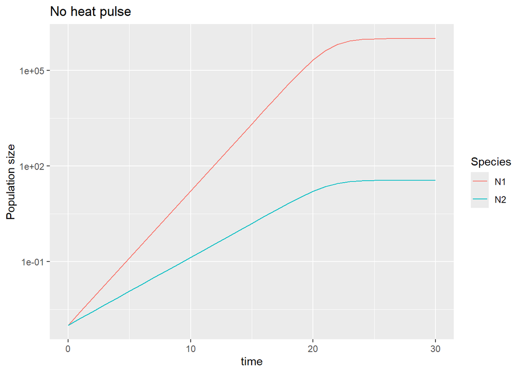

```r
# simulate the community WITHOUT heat pulse (i.e., no heat control)
simCTRL <- sim_1temp(time = 0:heat_pulse_times[3],
                   init = State,
                   params = c(K=carrying_cap, mu1=sp1_ambient, mu2=sp2_ambient))
# plot the no heat control:
ggplot(pivot_longer(simCTRL, cols = N1:N2),
       aes(x=time, y=value, colour=name)) +
  geom_line() +
  labs(title = "No heat pulse", y="Population size", colour = "Species") +
  scale_y_log10()
```

```r
################ let's look at the effect size in different ways:
effects_df <- heatVScontrol_effect(simdata_heat=simEX, simdata_control=simCTRL)

# plot per species
ggplot(effects_df %>%
         select(time, N1, N2) %>% pivot_longer(cols = N1:N2),
       aes(x=time, y=value, colour=name)) +
  geom_line() +
  labs(title = "Effect size on each species (pulse - control)", y="Change in population size", colour = "Species")
```

```r
# total productivity
ggplot(effects_df %>%
         select(time, productivity),
       aes(x=time, y=productivity)) +
  geom_line() +
  labs(title = "Effect size on total productivity (pulse - control)", y="Change in productivity")
```

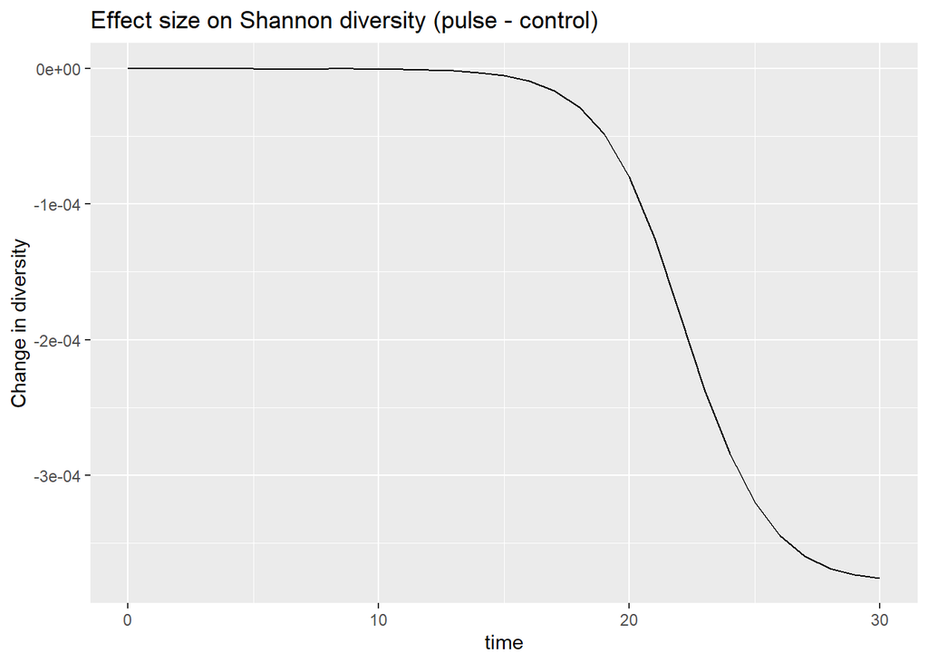

```r
# Shannon diversity
ggplot(effects_df %>%
         select(time, diversity),
       aes(x=time, y=diversity)) +
  geom_line() +
  labs(title = "Effect size on Shannon diversity (pulse - control)", y="Change in diversity")
```

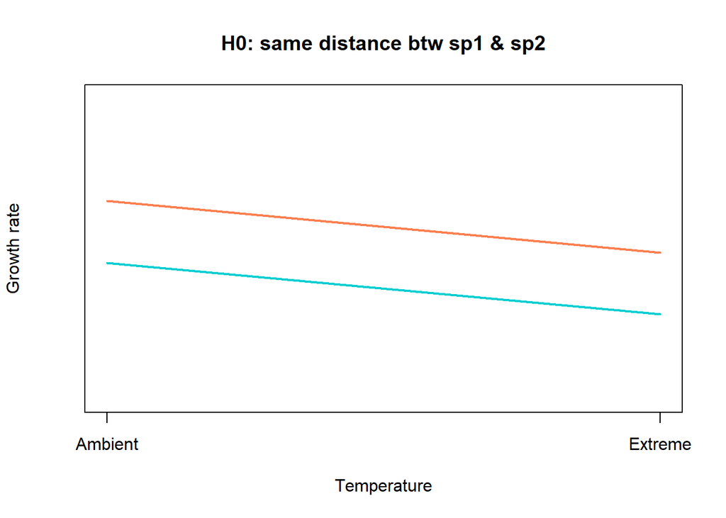

```r
# finally, we store the resistance vs recovery values for both productivity and diversity
RR_df <- data.frame(prod_resist = effects_df$productivity[which(effects_df$time == heat_pulse_times[2])],
                    prod_recov = effects_df$productivity[which(effects_df$time == heat_pulse_times[3])],
                    div_resist = effects_df$diversity[which(effects_df$time == heat_pulse_times[2])],
                    div_recov = effects_df$diversity[which(effects_df$time == heat_pulse_times[3])],
                    spF_ambient = sp1_ambient,
                    spF_extreme = sp1_extreme,
                    spS_ambient = sp2_ambient,
                    spS_extreme = sp2_extreme,
                    hypoth = "H0: same distance")


##################################### Try again with fixed distance:
sp2_ambient <- 0.36
sp2_extreme <- -0.15

plot_muSchematic(fast_ambient = sp1_ambient, fast_extreme = sp1_extreme,
                 slo_ambient = sp2_ambient, slo_extreme = sp2_extreme,
                 plot_title = "H0: same distance btw sp1 & sp2")
```

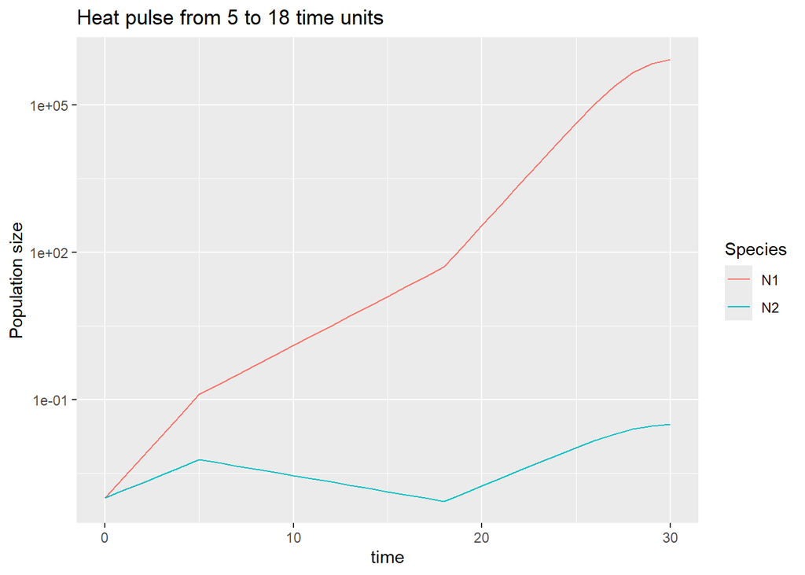

```r
# simulate the community with heat pulse
simEX <- sim_pulse(times=heat_pulse_times, init=State, K=carrying_cap,
                   mu_ambient=c(mu1=sp1_ambient, mu2=sp2_ambient), mu_extreme=c(mu1=sp1_extreme, mu2=sp2_extreme))

# plot the example under heat pulse conditions
ggplot(pivot_longer(simEX, cols = N1:N2),
       aes(x=time, y=value, colour=name)) +
  geom_line() +
  labs(title = "Heat pulse from 5 to 18 time units", y="Population size", colour = "Species") +
  scale_y_log10()
```

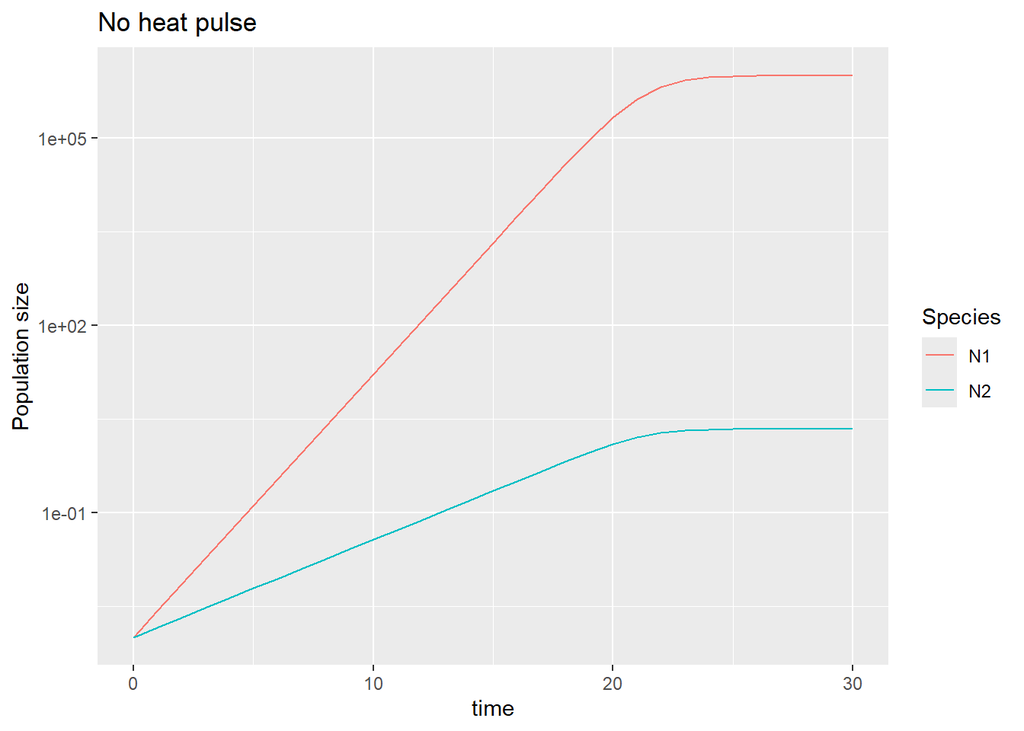

```r
# simulate the community WITHOUT heat pulse (i.e., no heat control)
simCTRL <- sim_1temp(time = 0:heat_pulse_times[3],
                   init = State,
                   params = c(K=carrying_cap, mu1=sp1_ambient, mu2=sp2_ambient))
# plot the no heat control:
ggplot(pivot_longer(simCTRL, cols = N1:N2),
       aes(x=time, y=value, colour=name)) +
  geom_line() +
  labs(title = "No heat pulse", y="Population size", colour = "Species") +
  scale_y_log10()
```

```r
################ let's look at the effect size in different ways:
effects_df <- heatVScontrol_effect(simdata_heat=simEX, simdata_control=simCTRL)

# plot per species
ggplot(effects_df %>%
         select(time, N1, N2) %>% pivot_longer(cols = N1:N2),
       aes(x=time, y=value, colour=name)) +
  geom_line() +
  labs(title = "Effect size on each species (pulse - control)", y="Change in population size", colour = "Species")
```

```r
# total productivity
ggplot(effects_df %>%
         select(time, productivity),
       aes(x=time, y=productivity)) +
  geom_line() +
  labs(title = "Effect size on total productivity (pulse - control)", y="Change in productivity")
```

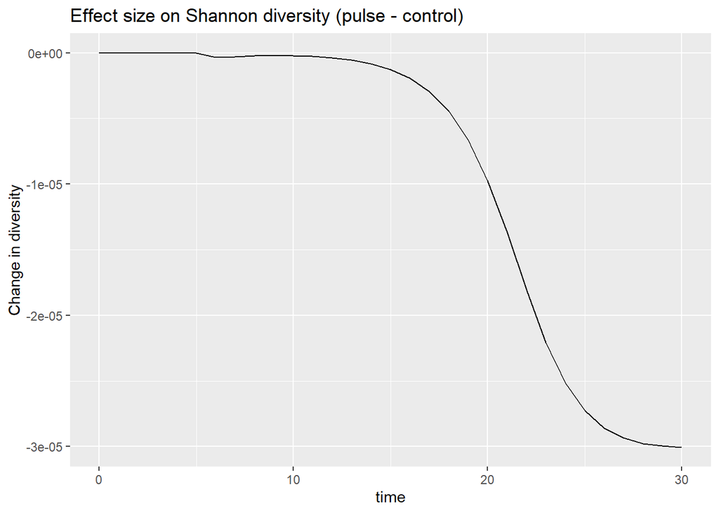

```r
# Shannon diversity
ggplot(effects_df %>%
         select(time, diversity),
       aes(x=time, y=diversity)) +
  geom_line() +
  labs(title = "Effect size on Shannon diversity (pulse - control)", y="Change in diversity")
```

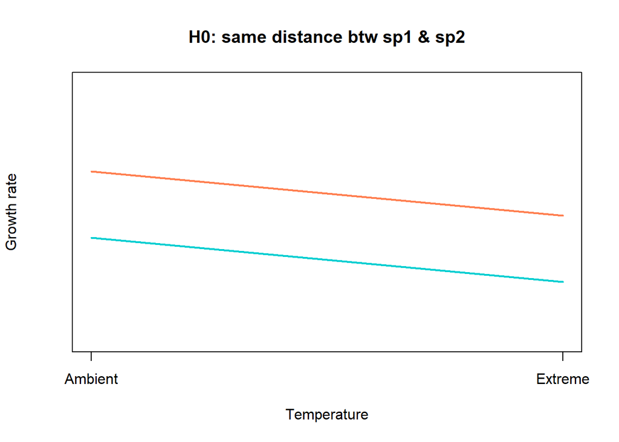

```r
# finally, we store the resistance vs recovery values for both productivity and diversity
temp <- data.frame(prod_resist = effects_df$productivity[which(effects_df$time == heat_pulse_times[2])],
                    prod_recov = effects_df$productivity[which(effects_df$time == heat_pulse_times[3])],
                    div_resist = effects_df$diversity[which(effects_df$time == heat_pulse_times[2])],
                    div_recov = effects_df$diversity[which(effects_df$time == heat_pulse_times[3])],
                    spF_ambient = sp1_ambient,
                    spF_extreme = sp1_extreme,
                    spS_ambient = sp2_ambient,
                    spS_extreme = sp2_extreme,
                    hypoth = "H0: same distance")
RR_df <- rbind(RR_df, temp)
rm(temp)
# clear memory
rm(simEX, simCTRL, effects_df)


##################################### aaaaand yet again with fixed distance:
sp2_ambient <- 0.2
sp2_extreme <- -0.31

plot_muSchematic(fast_ambient = sp1_ambient, fast_extreme = sp1_extreme,
                 slo_ambient = sp2_ambient, slo_extreme = sp2_extreme,
                 plot_title = "H0: same distance btw sp1 & sp2")
```

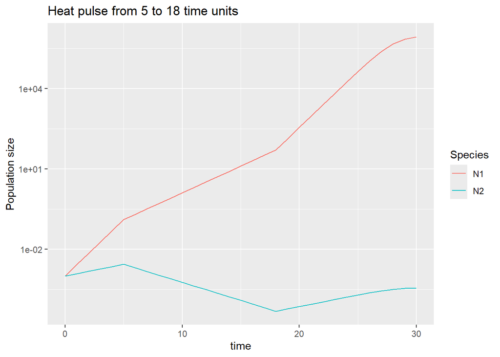

```r
# simulate the community with heat pulse
simEX <- sim_pulse(times=heat_pulse_times, init=State, K=carrying_cap,
                   mu_ambient=c(mu1=sp1_ambient, mu2=sp2_ambient), mu_extreme=c(mu1=sp1_extreme, mu2=sp2_extreme))

# plot the example under heat pulse conditions
ggplot(pivot_longer(simEX, cols = N1:N2),
       aes(x=time, y=value, colour=name)) +
  geom_line() +
  labs(title = "Heat pulse from 5 to 18 time units", y="Population size", colour = "Species") +
  scale_y_log10()
```

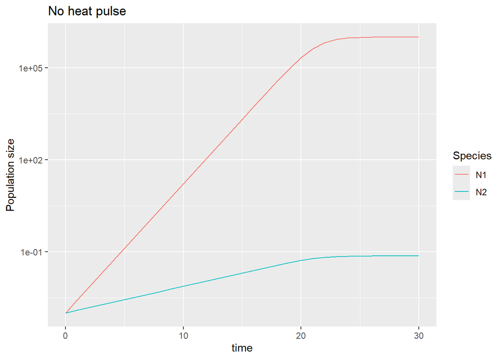

```r
# simulate the community WITHOUT heat pulse (i.e., no heat control)
simCTRL <- sim_1temp(time = 0:heat_pulse_times[3],
                   init = State,
                   params = c(K=carrying_cap, mu1=sp1_ambient, mu2=sp2_ambient))
# plot the no heat control:
ggplot(pivot_longer(simCTRL, cols = N1:N2),
       aes(x=time, y=value, colour=name)) +
  geom_line() +
  labs(title = "No heat pulse", y="Population size", colour = "Species") +
  scale_y_log10()
```

```r
################ let's look at the effect size in different ways:
effects_df <- heatVScontrol_effect(simdata_heat=simEX, simdata_control=simCTRL)

# plot per species
ggplot(effects_df %>%
         select(time, N1, N2) %>% pivot_longer(cols = N1:N2),
       aes(x=time, y=value, colour=name)) +
  geom_line() +
  labs(title = "Effect size on each species (pulse - control)", y="Change in population size", colour = "Species")
```

[output not shown]

```r
# total productivity
ggplot(effects_df %>%
         select(time, productivity),
       aes(x=time, y=productivity)) +
  geom_line() +
  labs(title = "Effect size on total productivity (pulse - control)", y="Change in productivity")
```

[output not shown]

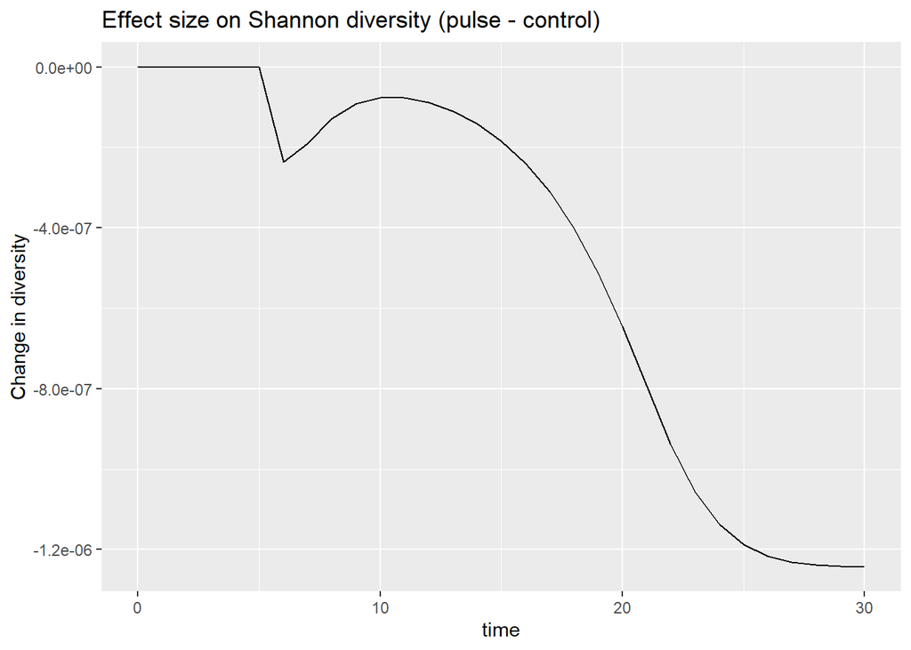

```r
# Shannon diversity
ggplot(effects_df %>%
         select(time, diversity),
       aes(x=time, y=diversity)) +
  geom_line() +
  labs(title = "Effect size on Shannon diversity (pulse - control)", y="Change in diversity")
```

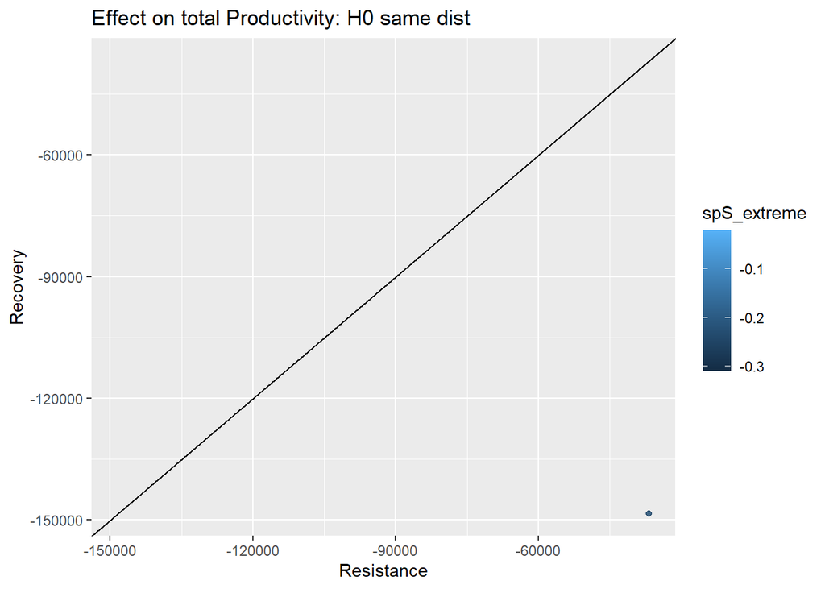

```r
# finally, we store the resistance vs recovery values for both productivity and diversity
temp <- data.frame(prod_resist = effects_df$productivity[which(effects_df$time == heat_pulse_times[2])],
                    prod_recov = effects_df$productivity[which(effects_df$time == heat_pulse_times[3])],
                    div_resist = effects_df$diversity[which(effects_df$time == heat_pulse_times[2])],
                    div_recov = effects_df$diversity[which(effects_df$time == heat_pulse_times[3])],
                    spF_ambient = sp1_ambient,
                    spF_extreme = sp1_extreme,
                    spS_ambient = sp2_ambient,
                    spS_extreme = sp2_extreme,
                    hypoth = "H0: same distance")
RR_df <- rbind(RR_df, temp)
rm(temp)
# clear memory
rm(simEX, simCTRL, effects_df)

##################### Finally we plot resistance vs recovery
ggplot(RR_df %>% filter(hypoth == "H0: same distance"),
       aes(x = prod_resist, y = prod_recov, colour = spS_extreme)) +
  geom_point(alpha=0.5) +
  geom_abline(intercept = 0, slope = 1, color = "black") +
  xlim(range(unlist(RR_df[,1:2]))) +
  ylim(range(unlist(RR_df[,1:2]))) +
  labs(title = "Effect on total Productivity: H0 same dist", x="Resistance", y="Recovery")
```

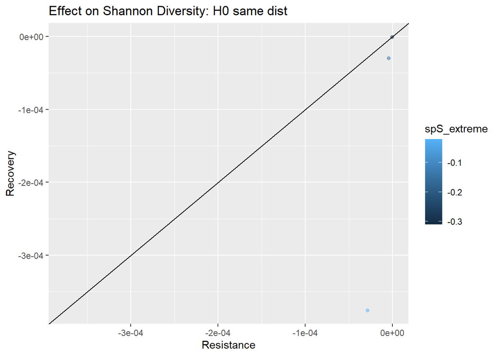

```r
ggplot(RR_df %>% filter(hypoth == "H0: same distance"),
       aes(x = div_resist, y = div_recov, colour = spS_extreme)) +
  geom_point(alpha=0.5) +
  geom_abline(intercept = 0, slope = 1, color = "black") +
  xlim(range(unlist(RR_df[,3:4]))) +
  ylim(range(unlist(RR_df[,3:4]))) +
  labs(title = "Effect on Shannon Diversity: H0 same dist", x="Resistance", y="Recovery")
```

```r
# keep these results for the final summary plot
final_RR_df <- rbind(final_RR_df,
                     RR_df)
```

### exponential, positive growth

I’m wondering if maybe my intuition is wrong that this whole model only works when there’s a carrying capacity. By setting a very high carrying capacity we can approximate the exponential model results without having to re-code anything…

```r
# keep all of these parameter values fixed:
#State <- c(N1=0.001, N2=0.001)
#heat_pulse_times <- c(5,18,30)
#sp1_ambient <- 0.97
#sp1_extreme <- 0.46
# but we change the carrying capacity:
carrying_cap <- 10^12

# just modify these two parameter values:
sp2_ambient <- 0.76
sp2_extreme <- 0.25

plot_muSchematic(fast_ambient = sp1_ambient, fast_extreme = sp1_extreme,
                 slo_ambient = sp2_ambient, slo_extreme = sp2_extreme,
                 plot_title = "H0: same distance btw sp1 & sp2")
```

[output not shown]

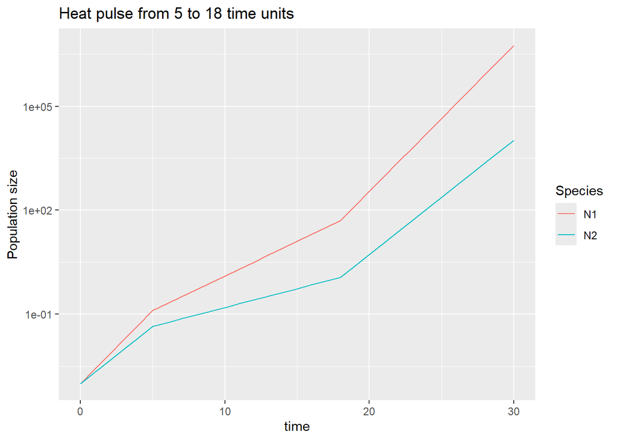

```r
# simulate the community with heat pulse
simEX <- sim_pulse(times=heat_pulse_times, init=State, K=carrying_cap,
                   mu_ambient=c(mu1=sp1_ambient, mu2=sp2_ambient), mu_extreme=c(mu1=sp1_extreme, mu2=sp2_extreme))

# plot the example under heat pulse conditions
ggplot(pivot_longer(simEX, cols = N1:N2),
       aes(x=time, y=value, colour=name)) +
  geom_line() +
  labs(title = "Heat pulse from 5 to 18 time units", y="Population size", colour = "Species") +
  scale_y_log10()
```

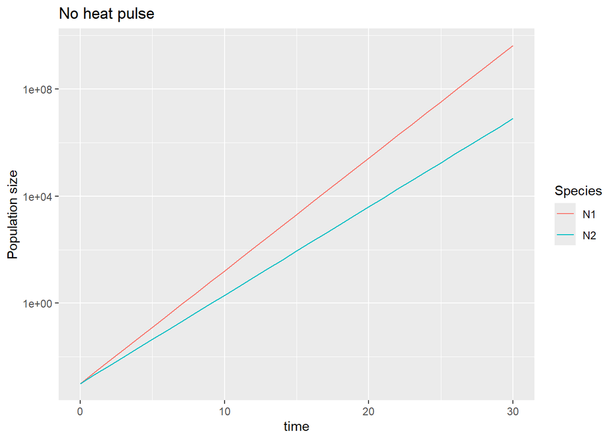

```r
# simulate the community WITHOUT heat pulse (i.e., no heat control)
simCTRL <- sim_1temp(time = 0:heat_pulse_times[3],
                   init = State,
                   params = c(K=carrying_cap, mu1=sp1_ambient, mu2=sp2_ambient))
# plot the no heat control:
ggplot(pivot_longer(simCTRL, cols = N1:N2),
       aes(x=time, y=value, colour=name)) +
  geom_line() +
  labs(title = "No heat pulse", y="Population size", colour = "Species") +
  scale_y_log10()
```

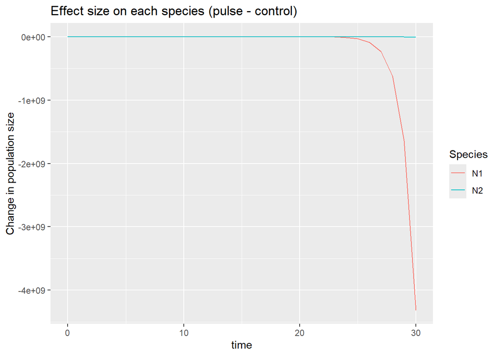

```r
################ let's look at the effect size in different ways:
effects_df <- heatVScontrol_effect(simdata_heat=simEX, simdata_control=simCTRL)

# plot per species
ggplot(effects_df %>%
         select(time, N1, N2) %>% pivot_longer(cols = N1:N2),
       aes(x=time, y=value, colour=name)) +
  geom_line() +
  labs(title = "Effect size on each species (pulse - control)", y="Change in population size", colour = "Species")
```

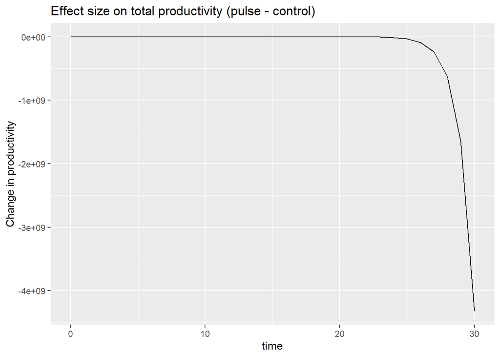

```r
# total productivity
ggplot(effects_df %>%
         select(time, productivity),
       aes(x=time, y=productivity)) +
  geom_line() +
  labs(title = "Effect size on total productivity (pulse - control)", y="Change in productivity")
```

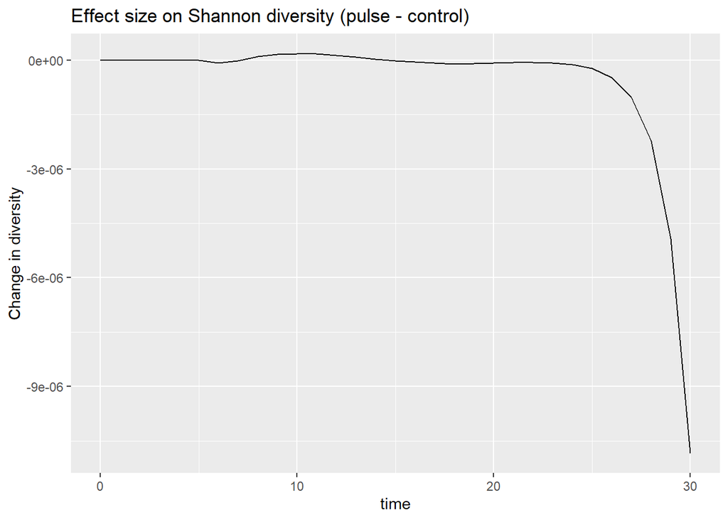

```r
# Shannon diversity
ggplot(effects_df %>%
         select(time, diversity),
       aes(x=time, y=diversity)) +
  geom_line() +
  labs(title = "Effect size on Shannon diversity (pulse - control)", y="Change in diversity")
```

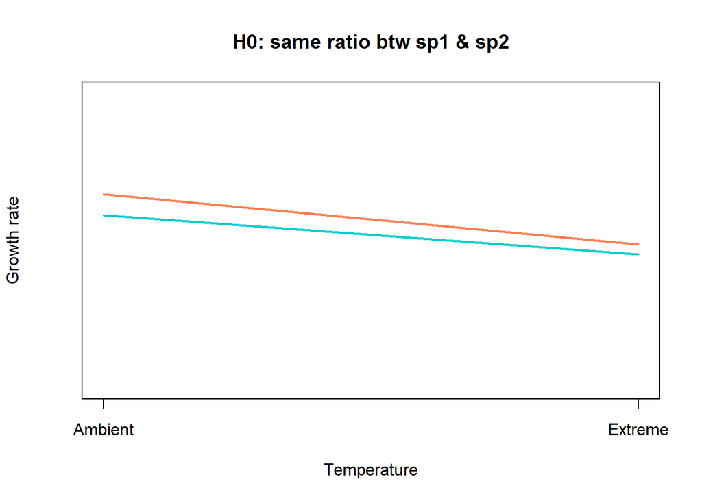

```r
# finally, we store the resistance vs recovery values for both productivity and diversity
RR_df <- data.frame(prod_resist = effects_df$productivity[which(effects_df$time == heat_pulse_times[2])],
                    prod_recov = effects_df$productivity[which(effects_df$time == heat_pulse_times[3])],
                    div_resist = effects_df$diversity[which(effects_df$time == heat_pulse_times[2])],
                    div_recov = effects_df$diversity[which(effects_df$time == heat_pulse_times[3])],
                    spF_ambient = sp1_ambient,
                    spF_extreme = sp1_extreme,
                    spS_ambient = sp2_ambient,
                    spS_extreme = sp2_extreme,
                    hypoth = "H0: same distance")



##################################### Try again:
sp2_ambient <- 0.76
sp2_extreme <- 0.36

plot_muSchematic(fast_ambient = sp1_ambient, fast_extreme = sp1_extreme,
                 slo_ambient = sp2_ambient, slo_extreme = sp2_extreme,
                 plot_title = "H0: same ratio btw sp1 & sp2")
```

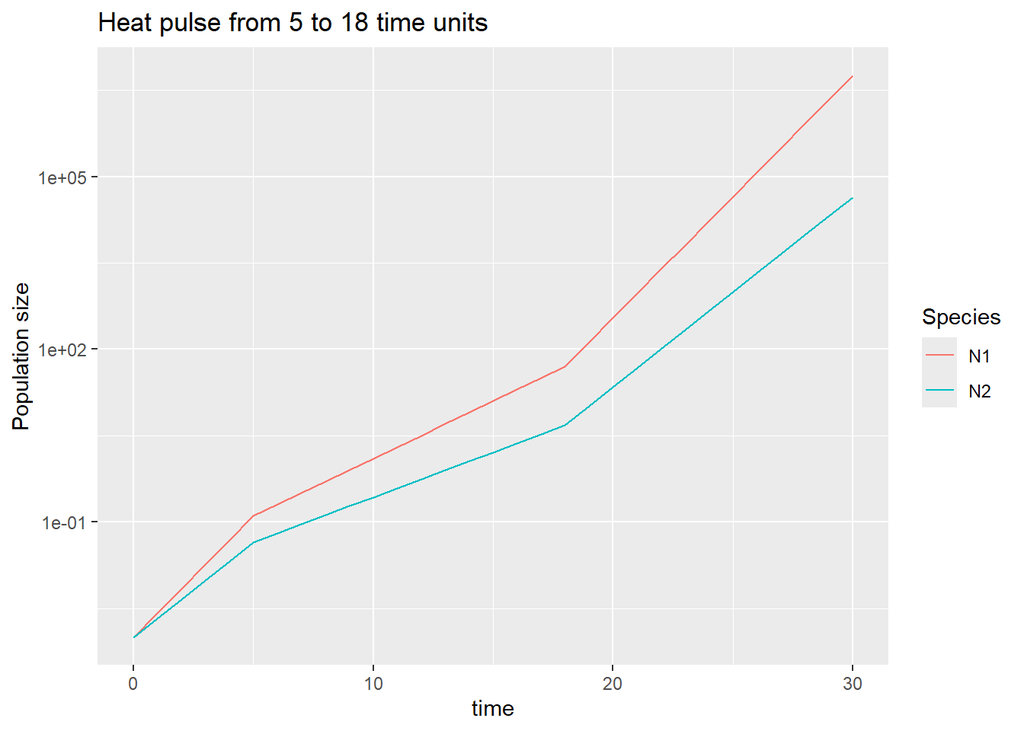

```r
# simulate the community with heat pulse
simEX <- sim_pulse(times=heat_pulse_times, init=State, K=carrying_cap,
                   mu_ambient=c(mu1=sp1_ambient, mu2=sp2_ambient), mu_extreme=c(mu1=sp1_extreme, mu2=sp2_extreme))

# plot the example under heat pulse conditions
ggplot(pivot_longer(simEX, cols = N1:N2),
       aes(x=time, y=value, colour=name)) +
  geom_line() +
  labs(title = "Heat pulse from 5 to 18 time units", y="Population size", colour = "Species") +
  scale_y_log10()
```

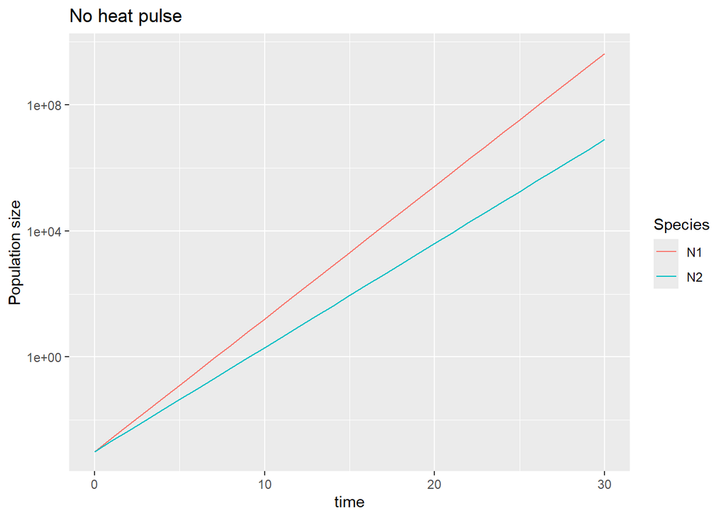

```r
# simulate the community WITHOUT heat pulse (i.e., no heat control)
simCTRL <- sim_1temp(time = 0:heat_pulse_times[3],
                   init = State,
                   params = c(K=carrying_cap, mu1=sp1_ambient, mu2=sp2_ambient))
# plot the no heat control:
ggplot(pivot_longer(simCTRL, cols = N1:N2),
       aes(x=time, y=value, colour=name)) +
  geom_line() +
  labs(title = "No heat pulse", y="Population size", colour = "Species") +
  scale_y_log10()
```

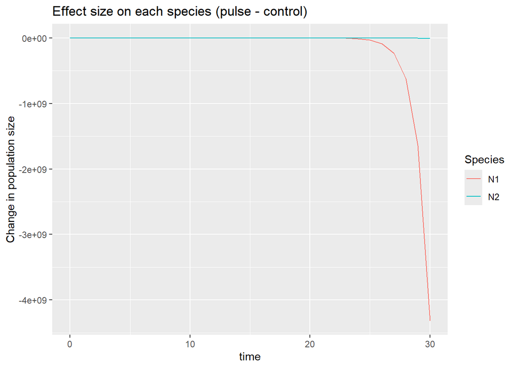

```r
################ let's look at the effect size in different ways:
effects_df <- heatVScontrol_effect(simdata_heat=simEX, simdata_control=simCTRL)

# plot per species
ggplot(effects_df %>%
         select(time, N1, N2) %>% pivot_longer(cols = N1:N2),
       aes(x=time, y=value, colour=name)) +
  geom_line() +
  labs(title = "Effect size on each species (pulse - control)", y="Change in population size", colour = "Species")
```

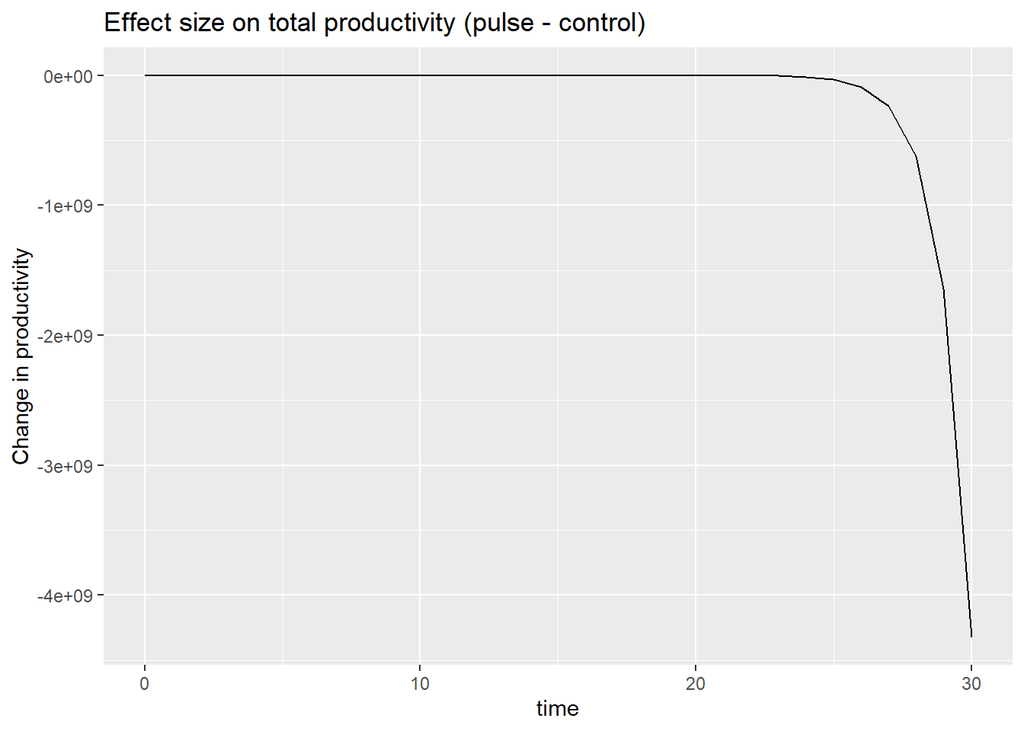

```r
# total productivity
ggplot(effects_df %>%
         select(time, productivity),
       aes(x=time, y=productivity)) +
  geom_line() +
  labs(title = "Effect size on total productivity (pulse - control)", y="Change in productivity")
```

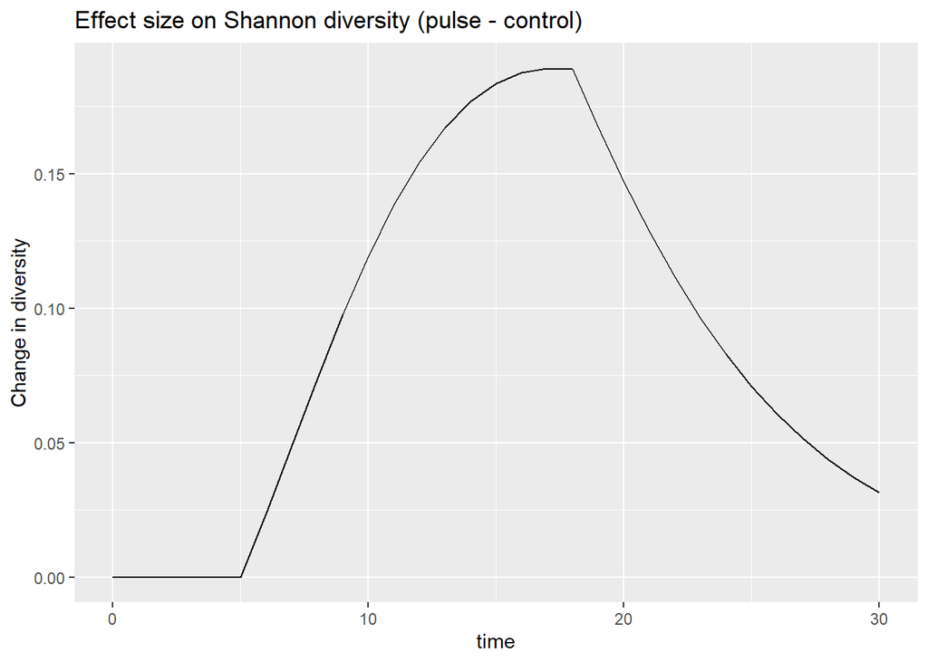

```r
# Shannon diversity
ggplot(effects_df %>%
         select(time, diversity),
       aes(x=time, y=diversity)) +
  geom_line() +
  labs(title = "Effect size on Shannon diversity (pulse - control)", y="Change in diversity")
```

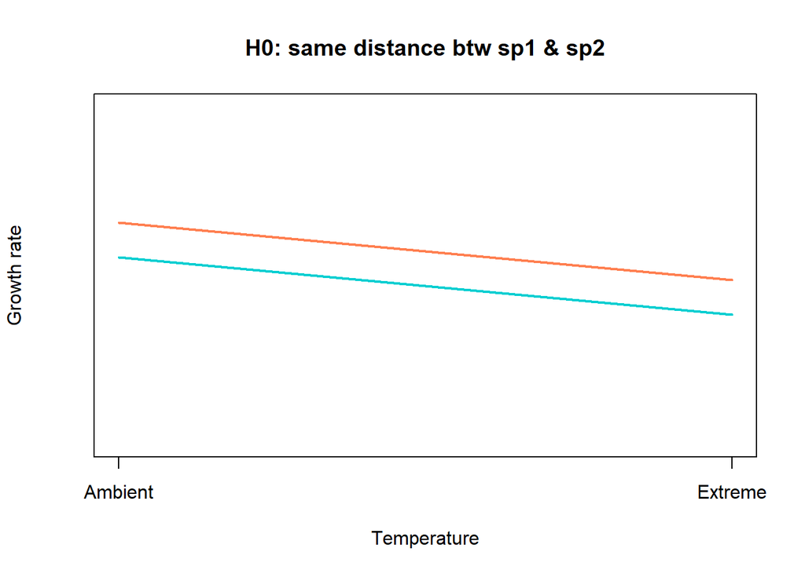

```r
# finally, we store the resistance vs recovery values for both productivity and diversity
temp <- data.frame(prod_resist = effects_df$productivity[which(effects_df$time == heat_pulse_times[2])],
                    prod_recov = effects_df$productivity[which(effects_df$time == heat_pulse_times[3])],
                    div_resist = effects_df$diversity[which(effects_df$time == heat_pulse_times[2])],
                    div_recov = effects_df$diversity[which(effects_df$time == heat_pulse_times[3])],
                    spF_ambient = sp1_ambient,
                    spF_extreme = sp1_extreme,
                    spS_ambient = sp2_ambient,
                    spS_extreme = sp2_extreme,
                    hypoth = "H0: same ratio")
RR_df <- rbind(RR_df, temp)
rm(temp)
# clear memory
rm(simEX, simCTRL, effects_df)


##################################### And again:
sp2_ambient <- 0.66
sp2_extreme <- 0.15

plot_muSchematic(fast_ambient = sp1_ambient, fast_extreme = sp1_extreme,
                 slo_ambient = sp2_ambient, slo_extreme = sp2_extreme,
                 plot_title = "H0: same distance btw sp1 & sp2")
```

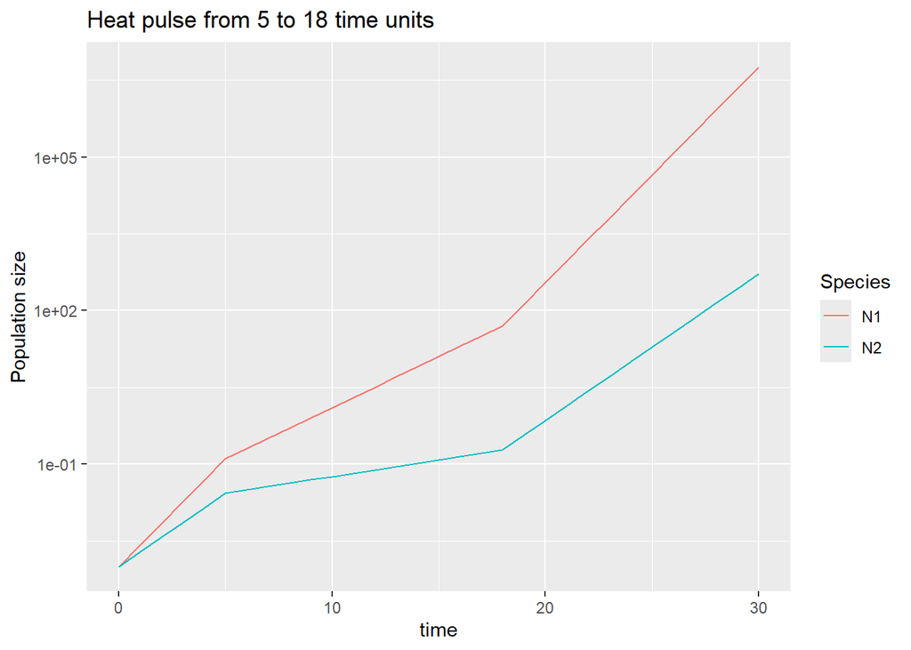

```r
# simulate the community with heat pulse
simEX <- sim_pulse(times=heat_pulse_times, init=State, K=carrying_cap,
                   mu_ambient=c(mu1=sp1_ambient, mu2=sp2_ambient), mu_extreme=c(mu1=sp1_extreme, mu2=sp2_extreme))

# plot the example under heat pulse conditions
ggplot(pivot_longer(simEX, cols = N1:N2),
       aes(x=time, y=value, colour=name)) +
  geom_line() +
  labs(title = "Heat pulse from 5 to 18 time units", y="Population size", colour = "Species") +
  scale_y_log10()
```

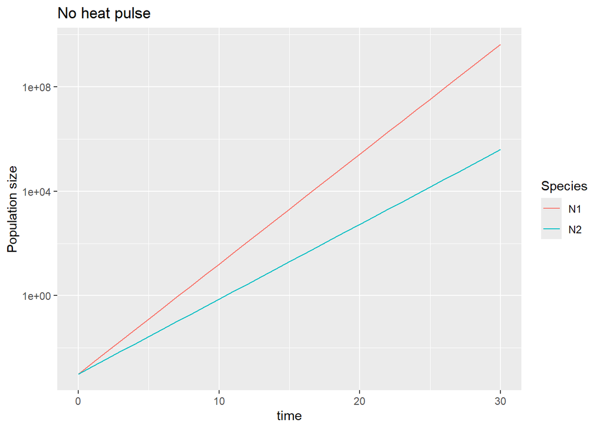

```r
# simulate the community WITHOUT heat pulse (i.e., no heat control)
simCTRL <- sim_1temp(time = 0:heat_pulse_times[3],
                   init = State,
                   params = c(K=carrying_cap, mu1=sp1_ambient, mu2=sp2_ambient))
# plot the no heat control:
ggplot(pivot_longer(simCTRL, cols = N1:N2),
       aes(x=time, y=value, colour=name)) +
  geom_line() +
  labs(title = "No heat pulse", y="Population size", colour = "Species") +
  scale_y_log10()
```

```r
################ let's look at the effect size in different ways:
effects_df <- heatVScontrol_effect(simdata_heat=simEX, simdata_control=simCTRL)

# plot per species
ggplot(effects_df %>%
         select(time, N1, N2) %>% pivot_longer(cols = N1:N2),
       aes(x=time, y=value, colour=name)) +
  geom_line() +
  labs(title = "Effect size on each species (pulse - control)", y="Change in population size", colour = "Species")
```

[output not shown]

```r
# total productivity
ggplot(effects_df %>%
         select(time, productivity),
       aes(x=time, y=productivity)) +
  geom_line() +
  labs(title = "Effect size on total productivity (pulse - control)", y="Change in productivity")
```

[output not shown]

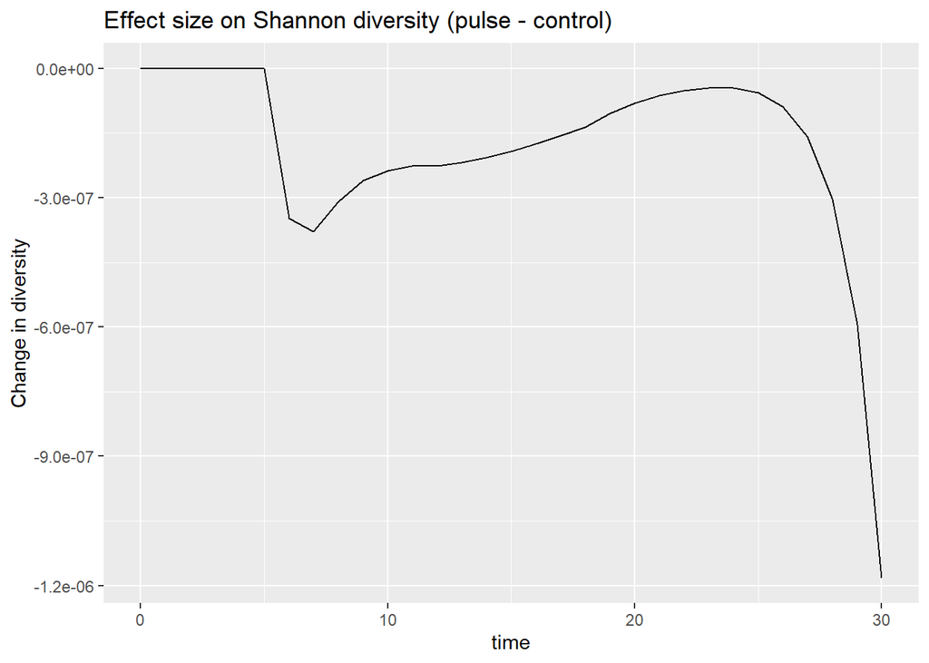

```r
# Shannon diversity
ggplot(effects_df %>%
         select(time, diversity),
       aes(x=time, y=diversity)) +
  geom_line() +
  labs(title = "Effect size on Shannon diversity (pulse - control)", y="Change in diversity")
```

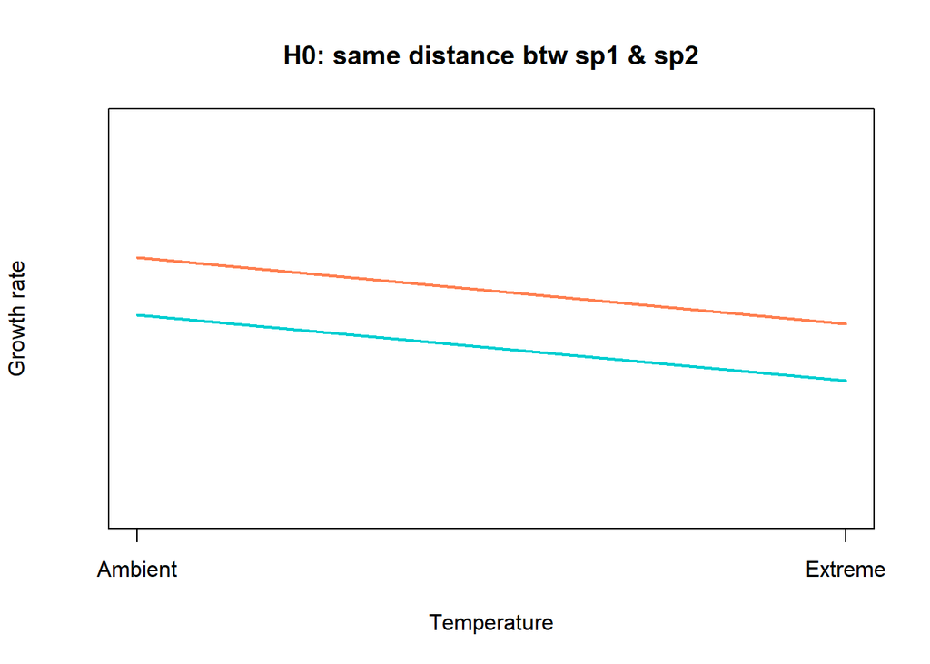

```r
# finally, we store the resistance vs recovery values for both productivity and diversity
temp <- data.frame(prod_resist = effects_df$productivity[which(effects_df$time == heat_pulse_times[2])],
                    prod_recov = effects_df$productivity[which(effects_df$time == heat_pulse_times[3])],
                    div_resist = effects_df$diversity[which(effects_df$time == heat_pulse_times[2])],
                    div_recov = effects_df$diversity[which(effects_df$time == heat_pulse_times[3])],
                    spF_ambient = sp1_ambient,
                    spF_extreme = sp1_extreme,
                    spS_ambient = sp2_ambient,
                    spS_extreme = sp2_extreme,
                    hypoth = "H0: same distance")
RR_df <- rbind(RR_df, temp)
rm(temp)
# clear memory
rm(simEX, simCTRL, effects_df)


##################################### aaaaand yet again:
sp2_ambient <- 0.53
sp2_extreme <- 0.02

plot_muSchematic(fast_ambient = sp1_ambient, fast_extreme = sp1_extreme,
                 slo_ambient = sp2_ambient, slo_extreme = sp2_extreme,
                 plot_title = "H0: same distance btw sp1 & sp2")
```

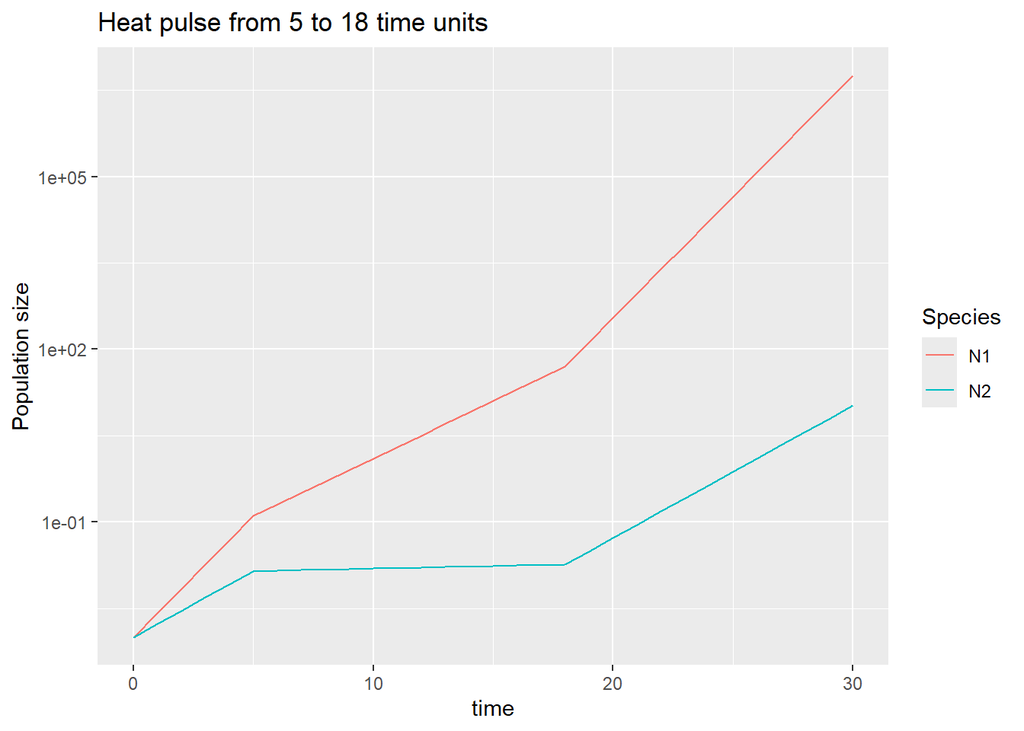

```r
# simulate the community with heat pulse
simEX <- sim_pulse(times=heat_pulse_times, init=State, K=carrying_cap,
                   mu_ambient=c(mu1=sp1_ambient, mu2=sp2_ambient), mu_extreme=c(mu1=sp1_extreme, mu2=sp2_extreme))

# plot the example under heat pulse conditions
ggplot(pivot_longer(simEX, cols = N1:N2),
       aes(x=time, y=value, colour=name)) +
  geom_line() +
  labs(title = "Heat pulse from 5 to 18 time units", y="Population size", colour = "Species") +
  scale_y_log10()
```

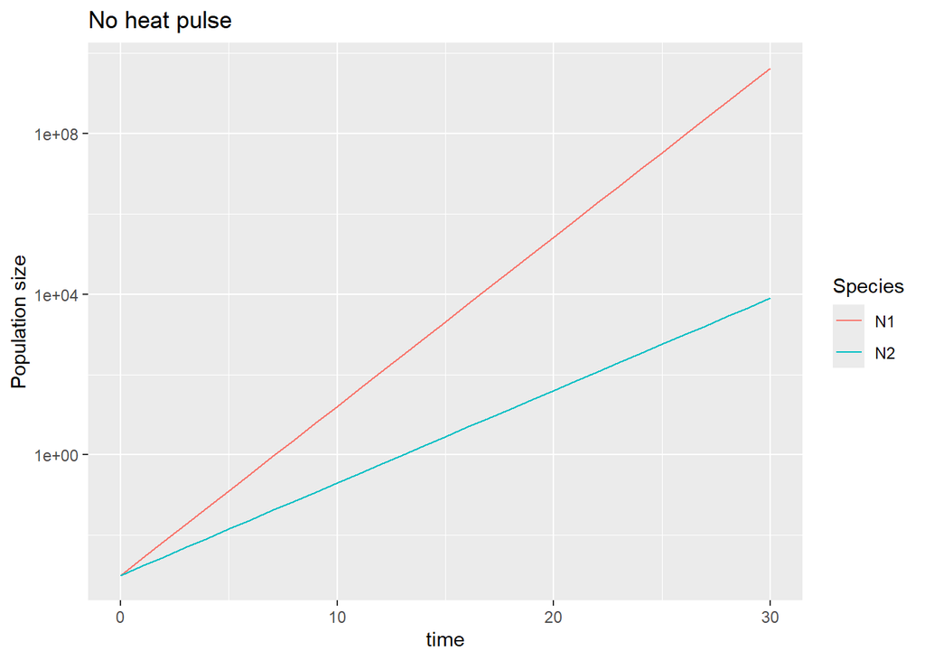

```r
# simulate the community WITHOUT heat pulse (i.e., no heat control)
simCTRL <- sim_1temp(time = 0:heat_pulse_times[3],
                   init = State,
                   params = c(K=carrying_cap, mu1=sp1_ambient, mu2=sp2_ambient))
# plot the no heat control:
ggplot(pivot_longer(simCTRL, cols = N1:N2),
       aes(x=time, y=value, colour=name)) +
  geom_line() +
  labs(title = "No heat pulse", y="Population size", colour = "Species") +
  scale_y_log10()
```

```r
################ let's look at the effect size in different ways:
effects_df <- heatVScontrol_effect(simdata_heat=simEX, simdata_control=simCTRL)

# plot per species
ggplot(effects_df %>%
         select(time, N1, N2) %>% pivot_longer(cols = N1:N2),
       aes(x=time, y=value, colour=name)) +
  geom_line() +
  labs(title = "Effect size on each species (pulse - control)", y="Change in population size", colour = "Species")
```

[output not shown]

```r
# total productivity
ggplot(effects_df %>%
         select(time, productivity),
       aes(x=time, y=productivity)) +
  geom_line() +
  labs(title = "Effect size on total productivity (pulse - control)", y="Change in productivity")
```

[output not shown]

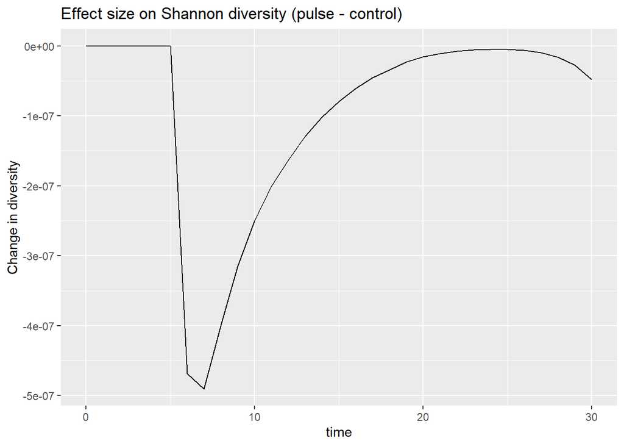

```r
# Shannon diversity
ggplot(effects_df %>%
         select(time, diversity),
       aes(x=time, y=diversity)) +
  geom_line() +
  labs(title = "Effect size on Shannon diversity (pulse - control)", y="Change in diversity")
```

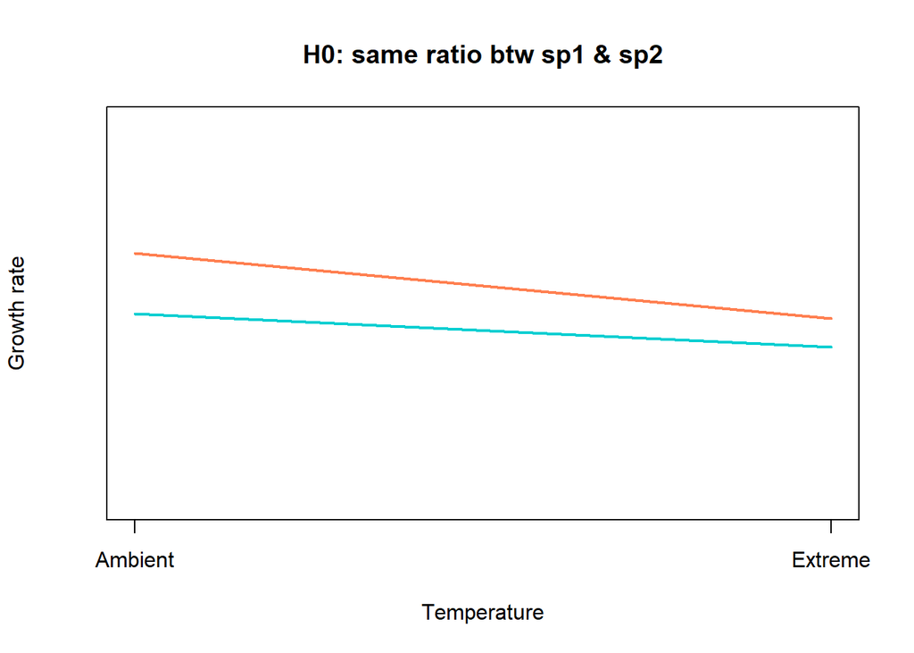

```r
# finally, we store the resistance vs recovery values for both productivity and diversity
temp <- data.frame(prod_resist = effects_df$productivity[which(effects_df$time == heat_pulse_times[2])],
                    prod_recov = effects_df$productivity[which(effects_df$time == heat_pulse_times[3])],
                    div_resist = effects_df$diversity[which(effects_df$time == heat_pulse_times[2])],
                    div_recov = effects_df$diversity[which(effects_df$time == heat_pulse_times[3])],
                    spF_ambient = sp1_ambient,
                    spF_extreme = sp1_extreme,
                    spS_ambient = sp2_ambient,
                    spS_extreme = sp2_extreme,
                    hypoth = "H0: same distance")
RR_df <- rbind(RR_df, temp)
rm(temp)
# clear memory
rm(simEX, simCTRL, effects_df)

##################################### now we do same ratio again:
sp2_ambient <- 0.4947
sp2_extreme <- 0.2346

plot_muSchematic(fast_ambient = sp1_ambient, fast_extreme = sp1_extreme,
                 slo_ambient = sp2_ambient, slo_extreme = sp2_extreme,
                 plot_title = "H0: same ratio btw sp1 & sp2")
```

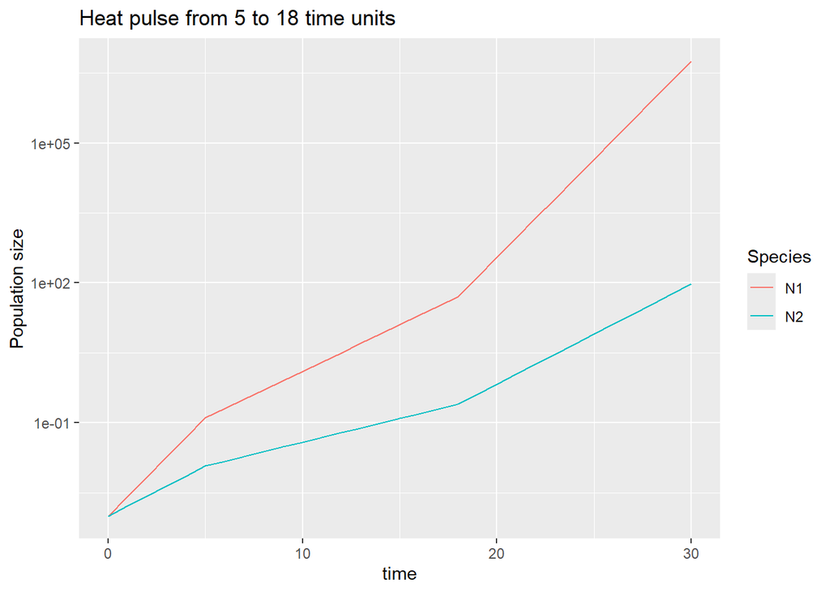

```r
# simulate the community with heat pulse
simEX <- sim_pulse(times=heat_pulse_times, init=State, K=carrying_cap,
                   mu_ambient=c(mu1=sp1_ambient, mu2=sp2_ambient), mu_extreme=c(mu1=sp1_extreme, mu2=sp2_extreme))

# plot the example under heat pulse conditions
ggplot(pivot_longer(simEX, cols = N1:N2),
       aes(x=time, y=value, colour=name)) +
  geom_line() +
  labs(title = "Heat pulse from 5 to 18 time units", y="Population size", colour = "Species") +
  scale_y_log10()
```

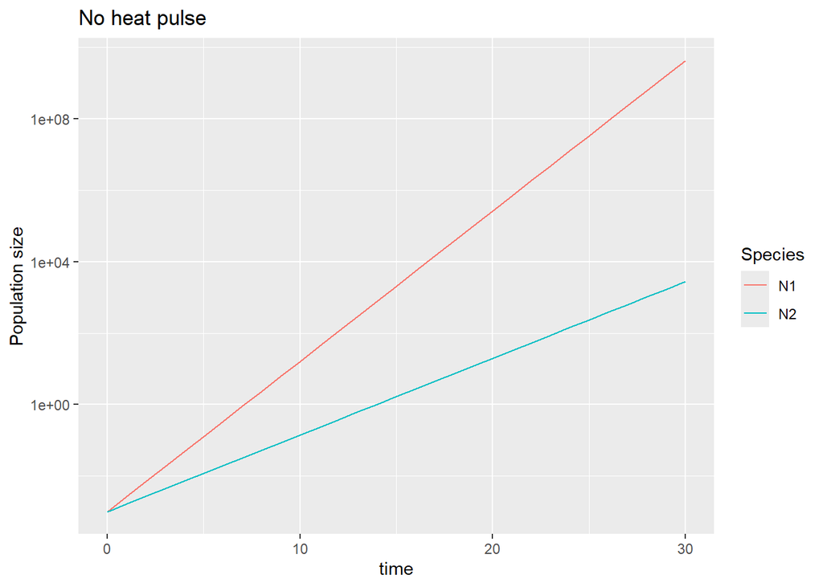

```r
# simulate the community WITHOUT heat pulse (i.e., no heat control)
simCTRL <- sim_1temp(time = 0:heat_pulse_times[3],
                   init = State,
                   params = c(K=carrying_cap, mu1=sp1_ambient, mu2=sp2_ambient))
# plot the no heat control:
ggplot(pivot_longer(simCTRL, cols = N1:N2),
       aes(x=time, y=value, colour=name)) +
  geom_line() +
  labs(title = "No heat pulse", y="Population size", colour = "Species") +
  scale_y_log10()
```

```r
################ let's look at the effect size in different ways:
effects_df <- heatVScontrol_effect(simdata_heat=simEX, simdata_control=simCTRL)

# plot per species
ggplot(effects_df %>%
         select(time, N1, N2) %>% pivot_longer(cols = N1:N2),
       aes(x=time, y=value, colour=name)) +
  geom_line() +
  labs(title = "Effect size on each species (pulse - control)", y="Change in population size", colour = "Species")
```

[output not shown]

```r
# total productivity
ggplot(effects_df %>%
         select(time, productivity),
       aes(x=time, y=productivity)) +
  geom_line() +
  labs(title = "Effect size on total productivity (pulse - control)", y="Change in productivity")
```

[output not shown]

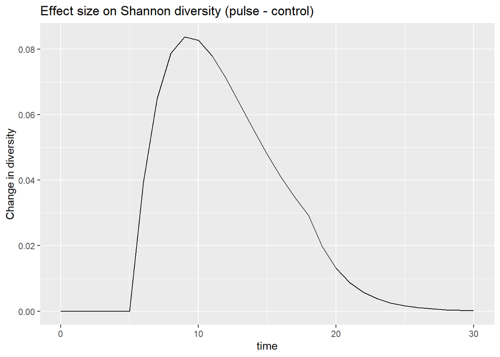

```r
# Shannon diversity
ggplot(effects_df %>%
         select(time, diversity),
       aes(x=time, y=diversity)) +
  geom_line() +
  labs(title = "Effect size on Shannon diversity (pulse - control)", y="Change in diversity")
```

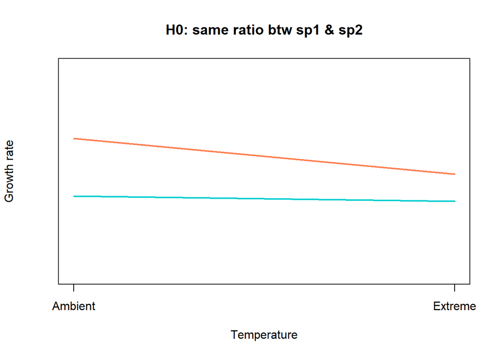

```r
# finally, we store the resistance vs recovery values for both productivity and diversity
temp <- data.frame(prod_resist = effects_df$productivity[which(effects_df$time == heat_pulse_times[2])],
                    prod_recov = effects_df$productivity[which(effects_df$time == heat_pulse_times[3])],
                    div_resist = effects_df$diversity[which(effects_df$time == heat_pulse_times[2])],
                    div_recov = effects_df$diversity[which(effects_df$time == heat_pulse_times[3])],
                    spF_ambient = sp1_ambient,
                    spF_extreme = sp1_extreme,
                    spS_ambient = sp2_ambient,
                    spS_extreme = sp2_extreme,
                    hypoth = "H0: same ratio")
RR_df <- rbind(RR_df, temp)
rm(temp)
# clear memory
rm(simEX, simCTRL, effects_df)


##################################### we do same ratio aaaaand yet again:
sp2_ambient <- 0.1455
sp2_extreme <- 0.069

plot_muSchematic(fast_ambient = sp1_ambient, fast_extreme = sp1_extreme,
                 slo_ambient = sp2_ambient, slo_extreme = sp2_extreme,
                 plot_title = "H0: same ratio btw sp1 & sp2")
```

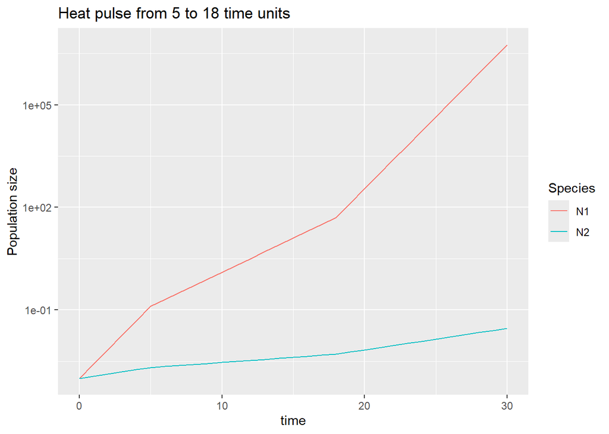

```r
# simulate the community with heat pulse
simEX <- sim_pulse(times=heat_pulse_times, init=State, K=carrying_cap,
                   mu_ambient=c(mu1=sp1_ambient, mu2=sp2_ambient), mu_extreme=c(mu1=sp1_extreme, mu2=sp2_extreme))

# plot the example under heat pulse conditions
ggplot(pivot_longer(simEX, cols = N1:N2),
       aes(x=time, y=value, colour=name)) +
  geom_line() +
  labs(title = "Heat pulse from 5 to 18 time units", y="Population size", colour = "Species") +
  scale_y_log10()
```

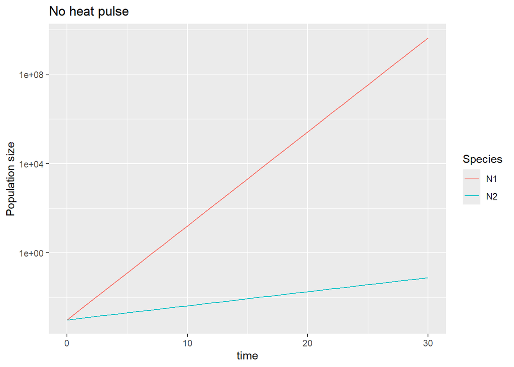

```r
# simulate the community WITHOUT heat pulse (i.e., no heat control)
simCTRL <- sim_1temp(time = 0:heat_pulse_times[3],
                   init = State,
                   params = c(K=carrying_cap, mu1=sp1_ambient, mu2=sp2_ambient))
# plot the no heat control:
ggplot(pivot_longer(simCTRL, cols = N1:N2),
       aes(x=time, y=value, colour=name)) +
  geom_line() +
  labs(title = "No heat pulse", y="Population size", colour = "Species") +
  scale_y_log10()
```

```r
################ let's look at the effect size in different ways:
effects_df <- heatVScontrol_effect(simdata_heat=simEX, simdata_control=simCTRL)

# plot per species
ggplot(effects_df %>%
         select(time, N1, N2) %>% pivot_longer(cols = N1:N2),
       aes(x=time, y=value, colour=name)) +
  geom_line() +
  labs(title = "Effect size on each species (pulse - control)", y="Change in population size", colour = "Species")
```

[output not shown]

```r
# total productivity
ggplot(effects_df %>%
         select(time, productivity),
       aes(x=time, y=productivity)) +
  geom_line() +
  labs(title = "Effect size on total productivity (pulse - control)", y="Change in productivity")
```

[output not shown]

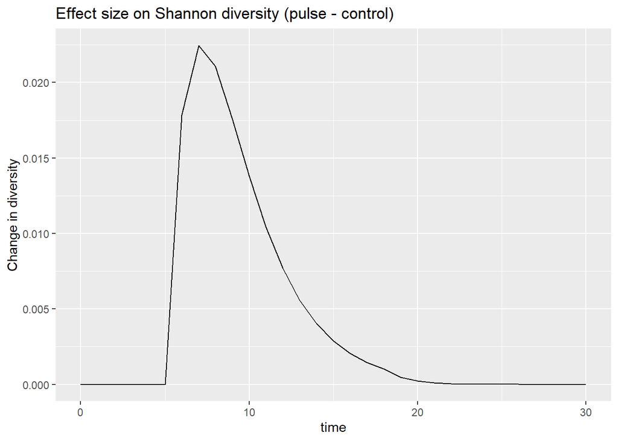

```r
# Shannon diversity
ggplot(effects_df %>%
         select(time, diversity),
       aes(x=time, y=diversity)) +
  geom_line() +
  labs(title = "Effect size on Shannon diversity (pulse - control)", y="Change in diversity")
```

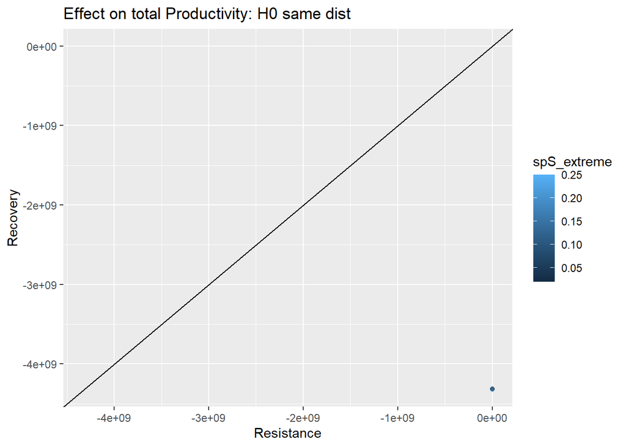

```r
# finally, we store the resistance vs recovery values for both productivity and diversity
temp <- data.frame(prod_resist = effects_df$productivity[which(effects_df$time == heat_pulse_times[2])],
                    prod_recov = effects_df$productivity[which(effects_df$time == heat_pulse_times[3])],
                    div_resist = effects_df$diversity[which(effects_df$time == heat_pulse_times[2])],
                    div_recov = effects_df$diversity[which(effects_df$time == heat_pulse_times[3])],
                    spF_ambient = sp1_ambient,
                    spF_extreme = sp1_extreme,
                    spS_ambient = sp2_ambient,
                    spS_extreme = sp2_extreme,
                    hypoth = "H0: same ratio")
RR_df <- rbind(RR_df, temp)
rm(temp)
# clear memory
rm(simEX, simCTRL, effects_df)

##################### Finally we plot resistance vs recovery
ggplot(RR_df %>% filter(hypoth == "H0: same distance"),
       aes(x = prod_resist, y = prod_recov, colour = spS_extreme)) +
  geom_point(alpha=0.5) +
  geom_abline(intercept = 0, slope = 1, color = "black") +
  xlim(range(unlist(RR_df[,1:2]))) +
  ylim(range(unlist(RR_df[,1:2]))) +
  labs(title = "Effect on total Productivity: H0 same dist", x="Resistance", y="Recovery")
```

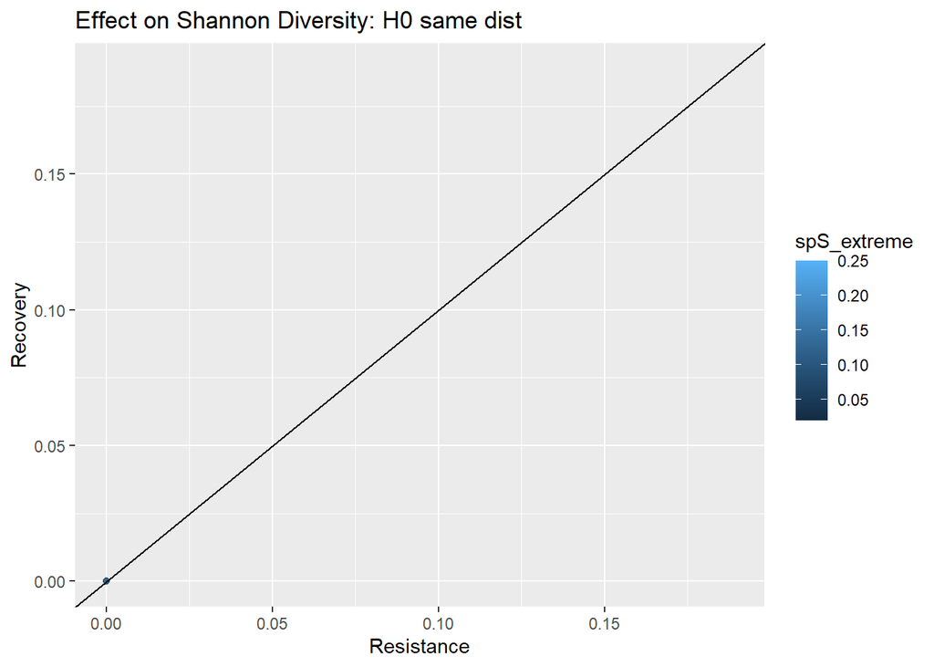

```r
ggplot(RR_df %>% filter(hypoth == "H0: same distance"),
       aes(x = div_resist, y = div_recov, colour = spS_extreme)) +
  geom_point(alpha=0.5) +
  geom_abline(intercept = 0, slope = 1, color = "black") +
  xlim(range(unlist(RR_df[,3:4]))) +
  ylim(range(unlist(RR_df[,3:4]))) +
  labs(title = "Effect on Shannon Diversity: H0 same dist", x="Resistance", y="Recovery")
```

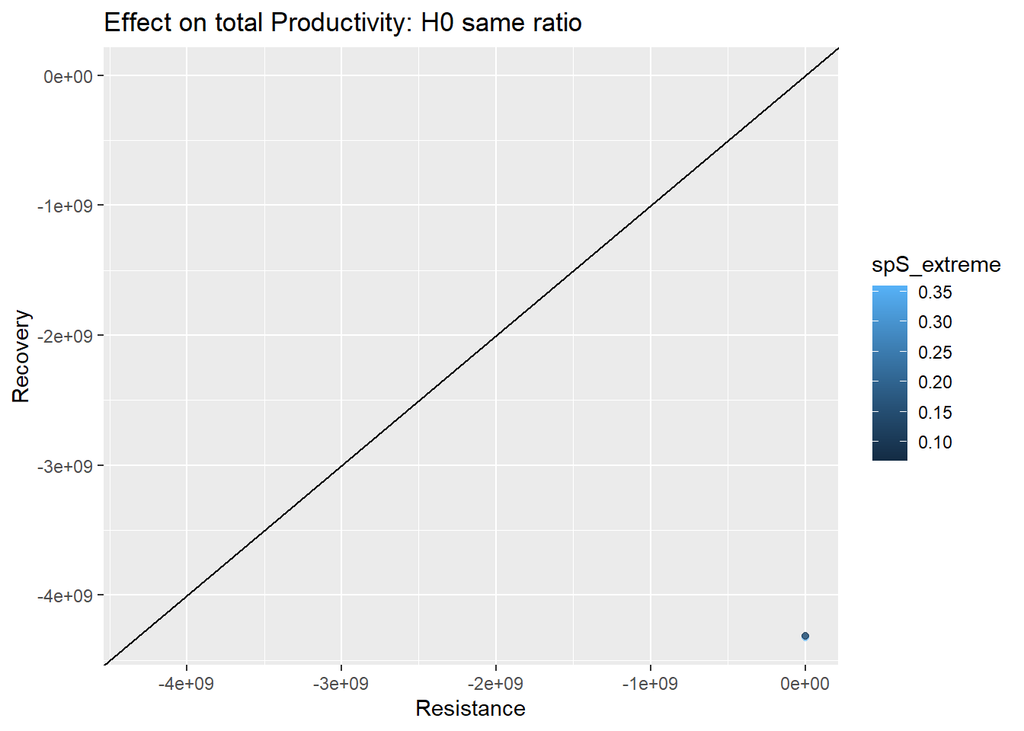

```r
ggplot(RR_df %>% filter(hypoth == "H0: same ratio"),
       aes(x = prod_resist, y = prod_recov, colour = spS_extreme)) +
  geom_point(alpha=0.5) +
  geom_abline(intercept = 0, slope = 1, color = "black") +
  xlim(range(unlist(RR_df[,1:2]))) +
  ylim(range(unlist(RR_df[,1:2]))) +
  labs(title = "Effect on total Productivity: H0 same ratio", x="Resistance", y="Recovery")
```

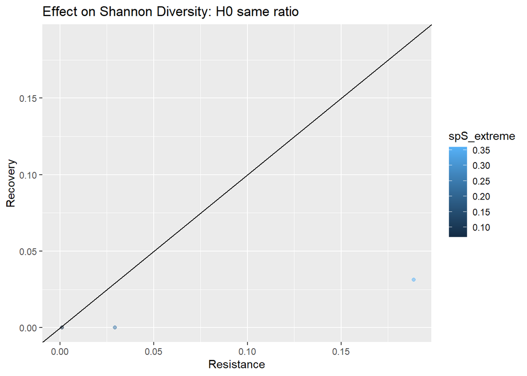

```r
ggplot(RR_df %>% filter(hypoth == "H0: same ratio"),
       aes(x = div_resist, y = div_recov, colour = spS_extreme)) +
  geom_point(alpha=0.5) +
  geom_abline(intercept = 0, slope = 1, color = "black") +
  xlim(range(unlist(RR_df[,3:4]))) +
  ylim(range(unlist(RR_df[,3:4]))) +
  labs(title = "Effect on Shannon Diversity: H0 same ratio", x="Resistance", y="Recovery")
```

Okay, at least my intuition of needing logistic growth in order to have have any chance at getting the resistance and recovery on similar orders of magnitude :P

### change fast grower (logistic)

I think that as the fast grower grows faster (slower), the effect size at recovery will be smaller (bigger).

```r
# keep all of these parameter values fixed:
#State <- c(N1=0.001, N2=0.001)
#heat_pulse_times <- c(5,18,30)
# return to the initial carrying capacity:
carrying_cap <- 10^6
# and fix the slow grower at the initial values:
sp2_ambient <- 0.76
sp2_extreme <- 0.25

# now we modify these two parameter values:
sp1_ambient <- 0.97
sp1_extreme <- 0.46

plot_muSchematic(fast_ambient = sp1_ambient, fast_extreme = sp1_extreme,
                 slo_ambient = sp2_ambient, slo_extreme = sp2_extreme,
                 plot_title = "H0: same distance btw sp1 & sp2")
```

[output not shown]

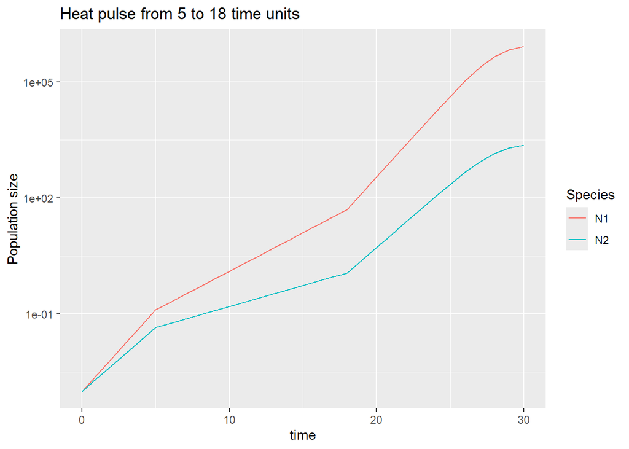

```r
# simulate the community with heat pulse
simEX <- sim_pulse(times=heat_pulse_times, init=State, K=carrying_cap,
                   mu_ambient=c(mu1=sp1_ambient, mu2=sp2_ambient), mu_extreme=c(mu1=sp1_extreme, mu2=sp2_extreme))

# plot the example under heat pulse conditions
ggplot(pivot_longer(simEX, cols = N1:N2),
       aes(x=time, y=value, colour=name)) +
  geom_line() +
  labs(title = "Heat pulse from 5 to 18 time units", y="Population size", colour = "Species") +
  scale_y_log10()
```

```r
# simulate the community WITHOUT heat pulse (i.e., no heat control)
simCTRL <- sim_1temp(time = 0:heat_pulse_times[3],
                   init = State,
                   params = c(K=carrying_cap, mu1=sp1_ambient, mu2=sp2_ambient))
# plot the no heat control:
ggplot(pivot_longer(simCTRL, cols = N1:N2),
       aes(x=time, y=value, colour=name)) +
  geom_line() +
  labs(title = "No heat pulse", y="Population size", colour = "Species") +
  scale_y_log10()
```

[output not shown]

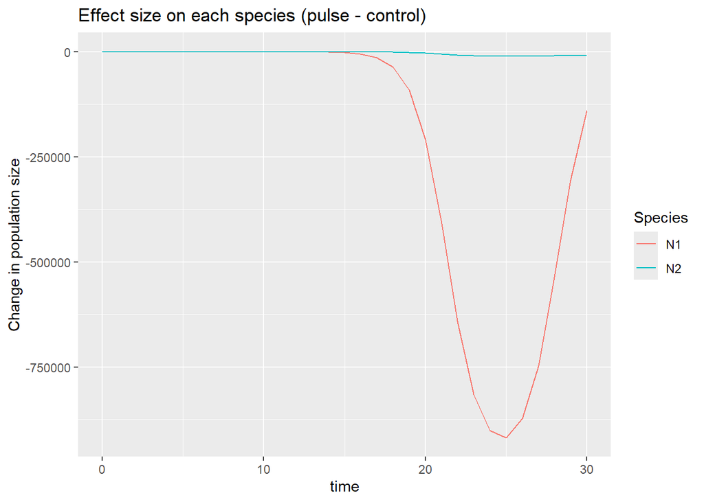

```r
################ let's look at the effect size in different ways:
effects_df <- heatVScontrol_effect(simdata_heat=simEX, simdata_control=simCTRL)

# plot per species
ggplot(effects_df %>%
         select(time, N1, N2) %>% pivot_longer(cols = N1:N2),
       aes(x=time, y=value, colour=name)) +
  geom_line() +
  labs(title = "Effect size on each species (pulse - control)", y="Change in population size", colour = "Species")
```

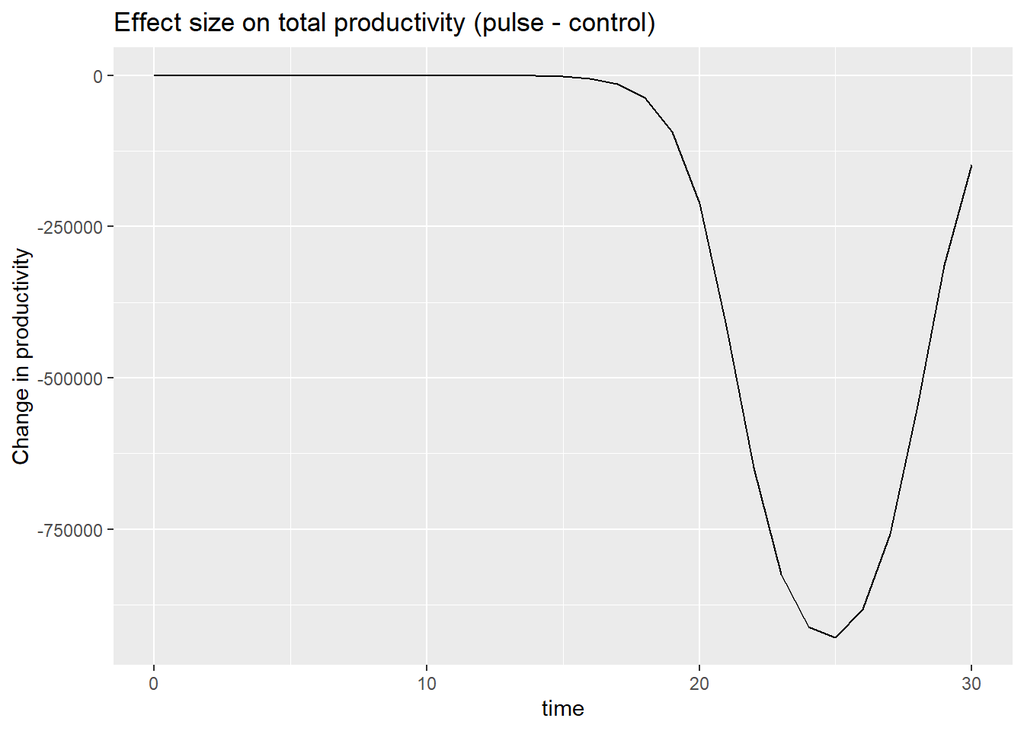

```r
# total productivity
ggplot(effects_df %>%
         select(time, productivity),
       aes(x=time, y=productivity)) +
  geom_line() +
  labs(title = "Effect size on total productivity (pulse - control)", y="Change in productivity")
```